# Cardiovascular Outcomes in Heart Failure Patients

Principal Investigator: John Kostis  
Co-Investigator: Michail Giakoumis, Georgia Barbayannis  
Statistician: Davit Sargsyan  
Date: Fri Nov 01 18:29:52 2019

# 1 Data

```r
load("data/case.RData")

# Make age per 10 year
case$decade <- floor(case$AGE/10)

# Discharge year as numeric
case$DSCYR <- as.numeric(case$DSCYR)

# Load hospital characteristics and merge
# Source: Georgia's Dakota project
dthosp <- fread("data/NJ HOSPITALS_Heart Attack Scores 2017.csv")
dthosp <- unique(dthosp[, c("Hospital Number",
                            "CLAB",
                            "Area",
                            "Teach")])
colnames(dthosp)[1] <- "HOSP"

# Remove hospitals with missing/ambiguous information
dthosp <- dthosp[-c(16, 45, 62, 73), ]

case$HOSP <- as.numeric(as.character(case$HOSP))
case <- merge(case,
              dthosp,
              by = "HOSP",
              all.x = TRUE)

case$CLAB[is.na(case$CLAB)] <- -1
case$CLAB <- factor(case$CLAB,
                    levels = rev((-1):1),
                    labels = c("Cath Lab",
                               "No Cath Lab",
                               "Unknown"))

case$Area[is.na(case$Area)] <- -1
case$Area <- factor(case$Area,
                    levels = c("U",
                               "I",
                               "R",
                               "S",
                               "-1"),
                    labels = c("Urban",
                               "Inner city",
                               "Rural",
                               "Suburb",
                               "Unknown"))

case$Teach[is.na(case$Teach)] <- -1
case$Teach <- factor(case$Teach,
                     levels = rev((-1):1),
                     labels = c("Teaching",
                                "Non-Teaching",
                                "Unknown"))
rcount.case <- format(nrow(case),
                      big.mark = ",")
```

Number of HF patients = 149,427

```r
# HF discharges----
t1 <- table(case$DSCYR)
t1 <- data.table(Year = as.integer(names(t1)),
                 Counts = c(t1))
dt.age <- aggregate(case$AGE,
                    by = list(Year = case$DSCYR),
                    FUN = "mean")
dt.age$x <- round(dt.age$x, 1)
names(dt.age)[2] <- "Age at 1st HF"

dt.age$Year <- as.numeric(dt.age$Year)

t1 <- merge(t1,
            dt.age,
            by = "Year")

write.csv(t1,
          file = "tmp/table1.csv",
          row.names = FALSE)

datatable(t1,
          caption = "Table 1: Number of first HF discharges by year",
          rownames = FALSE,
          class = "cell-border stripe",
          options = list(searching = TRUE,
                         pageLength = nrow(t1))) %>%
  formatCurrency(columns = 2,
                 currency = "",
                 digits = 0,
                 mark = ",")
```

| Year | Counts | Age at 1st HF |
| --- | --- | --- |
| 1995 | 14197 | 74.1 |
| 1996 | 10475 | 74.3 |
| 1997 | 9329 | 74 |
| 1998 | 8635 | 73.7 |
| 1999 | 7811 | 73.9 |
| 2000 | 7760 | 73.4 |
| 2001 | 7345 | 73.2 |
| 2002 | 7271 | 73 |
| 2003 | 7205 | 73.3 |
| 2004 | 6462 | 73 |

[output cut: 11 more lines]

# 2 Plot of number of new HF patients form 1995 to 2015

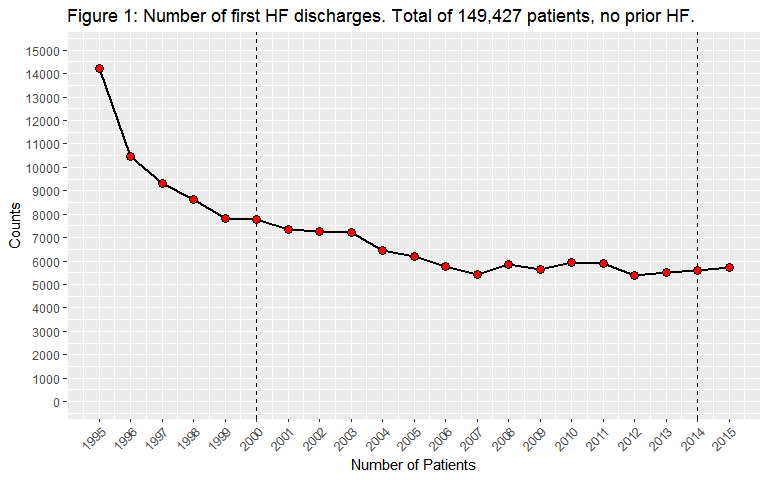

```r
p0 <- ggplot(t1,
             aes(x = Year,
                 y = Counts)) +
  geom_line(size = 1) +
  geom_vline(xintercept = c(2000, 2014),
             linetype = "dashed") +
  geom_point(size = 3,
             shape = 21,
             fill = "red") +
  scale_x_continuous("Number of Patients",
                     breaks = 1995:2015,
                     limits = c(1995, 2015)) +
  scale_y_continuous(breaks = seq(0, 15000, 1000),
                     limits = c(0, 15000)) +
  ggtitle(paste("Figure 1: Number of first HF discharges. Total of",
                rcount.case,
                "patients, no prior HF.")) +
  theme(axis.text.x = element_text(angle = 45,
                                   hjust = 1),
        plot.title = element_text(hjust = 0))
p0
```

**NOTE**: the higher number of patients in the early years could be due to censored records containing prior HF; hence, more patients remained. Also, we needed at least one year follow-up for all patients; hence, we restricted records to 2000-2014 interval.

# 3 Plot of number of new HF patients form 2000 to 2014

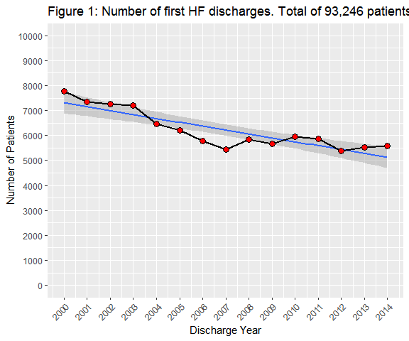

```r
t2 <- t1[Year > 1999 &
           Year < 2015, ]
# Plot HF discharges----
p0 <- ggplot(t2,
             aes(x = Year,
                 y = Counts)) +
  geom_smooth(method = "lm") +
  geom_line(size = 1) +
  geom_point(size = 3,
             shape = 21,
             fill = "red") +
  scale_x_continuous("Discharge Year",
                     breaks = 2000:2014,
                     limits = c(2000, 2014)) +
  scale_y_continuous("Number of Patients",
                     breaks = seq(0, 10000, 1000),
                     limits = c(0, 10000)) +
  ggtitle(paste("Figure 1: Number of first HF discharges. Total of",
                format(nrow(case[DSCYR > 1999 &
                                   DSCYR < 2015]),
                       big.mark = ","),
                "patients, no prior HF.")) +
  theme(axis.text.x = element_text(angle = 45,
                                   hjust = 1),
        plot.title = element_text(hjust = 0))

print(p0)
```

```r
# Linear trend
t2$years <- t2$Year - 2000
m1 <- lm(Counts ~ years,
         data = t2)

s1 <-summary(m1)

out1 <- data.table(Outcome = "New HF Admissions",
                   Slope = s1$coefficients[-1, 1],
                   `95% C.I.L.B.` = s1$coefficients[-1, 1] - 1.96*s1$coefficients[-1, 2],
                   `95% C.I.U.B.` = s1$coefficients[-1, 1] + 1.96*s1$coefficients[-1, 2],
                   `p-Value` = ifelse(s1$coefficients[-1, 4] >= 0.001,
                                 round(s1$coefficients[-1, 4], 3),
                                 "<0.001"),
                   Significance = ifelse(s1$coefficients[-1, 4] <= 0.05,
                                 ifelse(s1$coefficients[-1, 4] <= 0.01,
                                        "**",
                                        "*"), ""))
datatable(out1) %>%
  formatCurrency(columns = 2:4,
               currency = "",
               digits = 1,
               mark = ",")
```

|  | Outcome | Slope | 95% C.I.L.B. | 95% C.I.U.B. | p-Value | Significance |
| --- | --- | --- | --- | --- | --- | --- |
| 1 | New HF Admissions | -155.639285714286 | -202.324777071962 | -108.953794356609 | &lt;0.001 | ** |

# 4 Breakpoint model for number of first HF admissions

A breakpoint model fitted significantly better to the number of new HF over time data than did a sigle-line fit (ANOVA p-value < 0.001). Adding second breakpoint did not improve the fit (ANOVA p-value = 0.301)

```r
m1.1 <- segmented(m1)

# Compare with lm
anova(m1.1, m1)
```

```
Analysis of Variance Table

Model 1: Counts ~ years + U1.years + psi1.years
Model 2: Counts ~ years
  Res.Df     RSS Df Sum of Sq      F    Pr(>F)
1     11  474536
2     13 2065157 -2  -1590622 18.436 0.0003071 ***
---
Signif. codes:  0 ‘***’ 0.001 ‘**’ 0.01 ‘*’ 0.05 ‘.’ 0.1 ‘ ’ 1
```

```r
# Model 1: Counts ~ years + U1.years + psi1.years
# Model 2: Counts ~ years
#   Res.Df     RSS Df Sum of Sq      F    Pr(>F)
# 1     11  474536
# 2     13 2065157 -2  -1590622 18.436 0.0003071 ***
# IMPROVEMENT OVER LM: keep cahngepoint model

m1.2 <- segmented(m1, npsi = 2)
anova(m1.2, m1.1)
```

```
Analysis of Variance Table

Model 1: Counts ~ years + U1.years + U2.years + psi1.years + psi2.years
Model 2: Counts ~ years + U1.years + psi1.years
  Res.Df    RSS Df Sum of Sq      F Pr(>F)
1      9 363628
2     11 474536 -2   -110908 1.3725 0.3018
```

```r
# Analysis of Variance Table
# Model 1: Counts ~ years + U1.years + U2.years + psi1.years + psi2.years
# Model 2: Counts ~ years + U1.years + psi1.years
# Res.Df    RSS Df Sum of Sq     F Pr(>F)
# 1      9 363412
# 2     11 474536 -2   -111124 1.376  0.301
# NO IMPROVEMENT: keep the single-changepoint model

# Summary of the best model
m1.1
```

```
Call: segmented.lm(obj = m1)

Meaningful coefficients of the linear terms:
(Intercept)        years     U1.years
     7830.5       -323.7        305.6

Estimated Break-Point(s):
psi1.years
     6.499
```

```r
s1.1 <- summary(m1.1)
s1.1
```

```
    ***Regression Model with Segmented Relationship(s)***

Call:
segmented.lm(obj = m1)

Estimated Break-Point(s):
             Est. St.Err
psi1.years 6.499  0.708

Meaningful coefficients of the linear terms:
            Estimate Std. Error t value Pr(>|t|)
(Intercept)  7830.54     141.52  55.330 8.29e-15 ***
years        -323.75      39.25  -8.248 4.88e-06 ***
U1.years      305.60      50.67   6.031       NA
---
Signif. codes:  0 ‘***’ 0.001 ‘**’ 0.01 ‘*’ 0.05 ‘.’ 0.1 ‘ ’ 1

Residual standard error: 207.7 on 11 degrees of freedom
Multiple R-Squared: 0.9464,  Adjusted R-squared: 0.9317

Convergence attained in 3 iter. (rel. change 0)
```

```r
out.p <- data.table(bp = round(2000 + m1.1$psi[2], 1),
                    bplb = round(2000 + confint(m1.1)[2], 1),
                    bpub = round(2000 + confint(m1.1)[3], 1),
                    slope1 = round(s1.1$coefficients[2, 1], 1),
                    s1lb = round(s1.1$coefficients[2, 1] - qt(p = 0.975,
                                                              df = s1.1$df[2])*s1.1$coefficients[2, 2], 1),
                    s1ub = round(s1.1$coefficients[2, 1] + qt(p = 0.975,
                                                              df = s1.1$df[2])*s1.1$coefficients[2, 2], 1))

cp <- data.table(Year = 2000:2014,
                 predict(m1.1,
                         interval = "predict"))
```

```
predictions on current data refer to _future_ responses
```

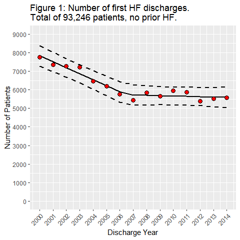

```r
p1 <- ggplot(t2,
             aes(x = Year,
                 y = Counts)) +
  geom_line(data = cp,
            aes(x = Year,
                y = fit),
            size = 1) +
  geom_line(data = cp,
            aes(x = Year,
                y = lwr),
            size = 1,
            linetype = "dashed") +
  geom_line(data = cp,
            aes(x = Year,
                y = upr),
            size = 1,
            linetype = "dashed") +
  geom_point(size = 3,
             shape = 21,
             fill = "red") +
  scale_x_continuous("Discharge Year",
                     breaks = 2000:2014,
                     limits = c(2000, 2014)) +
  scale_y_continuous("Number of Patients",
                     breaks = seq(0, 9000, 1000),
                     limits = c(0, 9000)) +
  ggtitle(paste("Figure 1: Number of first HF discharges.\nTotal of",
                format(nrow(case[DSCYR > 1999 &
                                   DSCYR < 2015]),
                       big.mark = ","),
                "patients, no prior HF.")) +
  theme(axis.text.x = element_text(angle = 45,
                                   hjust = 1),
        plot.title = element_text(hjust = 0))

# Save for publication
pp1 <- p1 +
  ggtitle("") +
  theme(legend.position = "none")
tiff(filename = "tmp/fig1.tiff",
     height = 5,
     width = 5,
     units = "in",
     res = 600,
     compression = "lzw+p")
print(pp1)
graphics.off()

p1
```

The breakpoint was estimated to be at the year 2006.5 (95% C.I. = 2004.9 to 2008.1). The number of new HF patients dicreased significantly between the years 2000 and 2006 by 323.7 patients on average (95% C.I. = -410.1 to -237.4, p-value < 0.001), and remained almost unchanged from 2007 onward.

**NOTE**: Javier suggested using a fixed breakpoint model so no model selection would be needed (i.e. no need to search for the model with the best breakpoint). not implemented in this document (yet!).

```r
case <- case[DSCYR > 1999 & DSCYR < 2015, ]

# ATTENTION! Save this data for Dhammika's and Javier's Machine Learning paper!
save(case,
     file = "data/midas_hf_admitted_2000_2014.RData")
```

# 5 Rates of outcomes

## 5.1 All-Cause Readmissions

```r
invisible({
  # 30 days----
  t1 <- addmargins(table(case$DSCYR,
                         case$days2readm < 31 &
                           !is.na(case$days2readm)))
  t1 <- data.table(dschyear = rownames(t1),
                   readm30 = t1[, 2],
                   N = t1[ , 3])
  t1[, rate := round(100*readm30/N, 2)]

  # 90 days----
  t2 <- addmargins(table(case$DSCYR,
                         case$days2readm < 91 &
                           !is.na(case$days2readm)))
  t2 <- data.table(dschyear = rownames(t2),
                   readm90 = t2[, 2],
                   N = t2[ , 3])
  t2[, rate := round(100*readm90/N, 2)]

  # 180 days----
  t3 <- addmargins(table(case$DSCYR,
                         case$days2readm < 181 &
                           !is.na(case$days2readm)))
  t3 <- data.table(dschyear = rownames(t3),
                   readm180 = t3[, 2],
                   N = t3[ , 3])
  t3[, rate := round(100*readm180/N, 2)]

  # 1 year----
  t4 <- addmargins(table(case$DSCYR,
                         case$days2readm < 366 &
                           !is.na(case$days2readm)))
  t4 <- data.table(dschyear = rownames(t4),
                   readm1y = t4[, 2],
                   N = t4[ , 3])
  t4[, rate := round(100*readm1y/N, 2)]

  # Combine----
  t1a.apx <- data.table(dschyear = t1$dschyear,
                        rate.30 = t1$rate,
                        rate.90 = t2$rate,
                        rate.180 = t3$rate,
                        rate.1y = t4$rate)
})

colnames(t1a.apx) <- c("HF Discharge Year",
                       "30-Day",
                       "90-Day",
                       "180-Day",
                       "1-Year")
write.csv(t1a.apx,
          file = "tmp/table3a.apx.csv",
          row.names = FALSE)

datatable(t1a.apx,
          caption = "Table 3a: all-cause readmissions (%)",
          rownames = FALSE,
          class = "cell-border stripe",
          options = list(searching = FALSE,
                         pageLength = nrow(t1a.apx)))
```

| HF Discharge Year | 30-Day | 90-Day | 180-Day | 1-Year |
| --- | --- | --- | --- | --- |
| 2000 | 15.89 | 29.03 | 38.48 | 50.08 |
| 2001 | 15.75 | 28.3 | 38.27 | 49.67 |
| 2002 | 16.39 | 30.06 | 39.94 | 51.15 |
| 2003 | 16.52 | 30.03 | 39.51 | 50.41 |
| 2004 | 16.2 | 30.05 | 40.1 | 51.5 |
| 2005 | 17.03 | 30.59 | 40.79 | 51.68 |
| 2006 | 16.88 | 30.36 | 40.05 | 50.9 |
| 2007 | 18.26 | 32.57 | 42.19 | 54.59 |
| 2008 | 21.18 | 36.19 | 46.25 | 57.59 |
| 2009 | 21.31 | 35.93 | 46.09 | 57.71 |

[output cut: 6 more lines]

## 5.2 HF Readmissions

```r
invisible({
  # 30 days----
  t1 <- addmargins(table(case$DSCYR,
                         case$days2post.hf.dx1 < 31 &
                           !is.na(case$days2post.hf.dx1)))
  t1 <- data.table(dschyear = rownames(t1),
                   hf30 = t1[, 2],
                   N = t1[ , 3])
  t1[, rate := round(100*hf30/N, 2)]

  # 90 days----
  t2 <- addmargins(table(case$DSCYR,
                         case$days2post.hf.dx1 < 91 &
                           !is.na(case$days2post.hf.dx1)))
  t2 <- data.table(dschyear = rownames(t2),
                   hf90 = t2[, 2],
                   N = t2[ , 3])
  t2[, rate := round(100*hf90/N, 2)]

  # 180 days----
  t3 <- addmargins(table(case$DSCYR,
                         case$days2post.hf.dx1 < 181 &
                           !is.na(case$days2post.hf.dx1)))
  t3 <- data.table(dschyear = rownames(t3),
                   hf180 = t3[, 2],
                   N = t3[ , 3])
  t3[, rate := round(100*hf180/N, 2)]

  # 1 year----
  t4 <- addmargins(table(case$DSCYR,
                         case$days2post.hf.dx1 < 366 &
                           !is.na(case$days2post.hf.dx1)))
  t4 <- data.table(dschyear = rownames(t4),
                   hf1y = t4[, 2],
                   N = t4[ , 3])
  t4[, rate := round(100*hf1y/N, 2)]

  # Combine----
  t1b.apx <- data.table(dschyear = t1$dschyear,
                        rate.30 = t1$rate,
                        rate.90 = t2$rate,
                        rate.180 = t3$rate,
                        rate.1y = t4$rate)
})
colnames(t1b.apx) <- c("HF Discharge Year",
                       "30-Day",
                       "90-Day",
                       "180-Day",
                       "1-Year")
write.csv(t1b.apx,
          file = "tmp/table3b.apx.csv",
          row.names = FALSE)

datatable(t1b.apx,
          caption = "Table 3b: HF readmissions (%)",
          rownames = FALSE,
          class = "cell-border stripe",
          options = list(searching = FALSE,
                         pageLength = nrow(t1b.apx)))
```

| HF Discharge Year | 30-Day | 90-Day | 180-Day | 1-Year |
| --- | --- | --- | --- | --- |
| 2000 | 5.62 | 10.27 | 13.89 | 18.88 |
| 2001 | 5.75 | 9.83 | 13.21 | 18.33 |
| 2002 | 5.46 | 10.19 | 14.07 | 19.32 |
| 2003 | 5.84 | 10.28 | 13.75 | 18.45 |
| 2004 | 5.83 | 10.85 | 15.29 | 20.15 |
| 2005 | 6.24 | 10.92 | 15.03 | 19.91 |
| 2006 | 6.62 | 11.63 | 15.56 | 19.84 |
| 2007 | 6.48 | 11.59 | 15.52 | 20.24 |
| 2008 | 7.09 | 11.91 | 15.88 | 20.63 |
| 2009 | 7.02 | 11.68 | 15.36 | 20.36 |

[output cut: 6 more lines]

## 5.3 All-Cause Death

```r
invisible({
  # 30 days----
  t1 <- addmargins(table(case$DSCYR,
                         case$days2death < 31 &
                           !is.na(case$days2death)))
  t1 <- data.table(dschyear = rownames(t1),
                   death30 = t1[, 2],
                   N = t1[ , 3])
  t1[, rate := round(100*death30/N, 2)]

  # 90 days----
  t2 <- addmargins(table(case$DSCYR,
                         case$days2death < 91 &
                           !is.na(case$days2death)))
  t2 <- data.table(dschyear = rownames(t2),
                   death90 = t2[, 2],
                   N = t2[ , 3])
  t2[, rate := round(100*death90/N, 2)]

  # 180 days----
  t3 <- addmargins(table(case$DSCYR,
                         case$days2death < 181 &
                           !is.na(case$days2death)))
  t3 <- data.table(dschyear = rownames(t3),
                   death180 = t3[, 2],
                   N = t3[ , 3])
  t3[, rate := round(100*death180/N, 2)]

  # 1 year----
  t4 <- addmargins(table(case$DSCYR,
                         case$days2death < 366 &
                           !is.na(case$days2death)))
  t4 <- data.table(dschyear = rownames(t4),
                   death1y = t4[, 2],
                   N = t4[ , 3])
  t4[, rate := round(100*death1y/N, 2)]

  # Combine----
  t1c.apx <- data.table(dschyear = t1$dschyear,
                        rate.30 = t1$rate,
                        rate.90 = t2$rate,
                        rate.180 = t3$rate,
                        rate.1y = t4$rate)
})
colnames(t1c.apx) <- c("HF Discharge Year",
                       "30-Day",
                       "90-Day",
                       "180-Day",
                       "1-Year")
write.csv(t1c.apx,
          file = "tmp/table3c.apx.csv",
          row.names = FALSE)

datatable(t1c.apx,
          caption = "Table 3c: all-cause death (%)",
          rownames = FALSE,
          class = "cell-border stripe",
          options = list(searching = FALSE,
                         pageLength = nrow(t1c.apx)))
```

| HF Discharge Year | 30-Day | 90-Day | 180-Day | 1-Year |
| --- | --- | --- | --- | --- |
| 2000 | 3.8 | 7.99 | 12.23 | 18.94 |
| 2001 | 3.89 | 7.8 | 12.09 | 18.34 |
| 2002 | 3.6 | 7.91 | 12.34 | 18.77 |
| 2003 | 4.36 | 9.48 | 13.89 | 20.22 |
| 2004 | 3.54 | 8.03 | 12.06 | 18.42 |
| 2005 | 4.18 | 8.98 | 13.17 | 19.51 |
| 2006 | 4.49 | 9.38 | 12.81 | 18.61 |
| 2007 | 3.97 | 8.91 | 13.1 | 18.83 |
| 2008 | 4.46 | 8.77 | 12.66 | 18.59 |
| 2009 | 4.52 | 9.68 | 14.1 | 20.22 |

[output cut: 6 more lines]

## 5.4 CV Death

```r
invisible({
  # 30 days----
  t1 <- addmargins(table(case$DSCYR,
                         case$days2cvdeath < 31 &
                           !is.na(case$days2cvdeath)))
  t1 <- data.table(dschyear = rownames(t1),
                   cvdeath30 = t1[, 2],
                   N = t1[ , 3])
  t1[, rate := round(100*cvdeath30/N, 2)]

  # 90 days----
  t2 <- addmargins(table(case$DSCYR,
                         case$days2cvdeath < 91 &
                           !is.na(case$days2cvdeath)))
  t2 <- data.table(dschyear = rownames(t2),
                   cvdeath90 = t2[, 2],
                   N = t2[ , 3])
  t2[, rate := round(100*cvdeath90/N, 2)]

  # 180 days----
  t3 <- addmargins(table(case$DSCYR,
                         case$days2cvdeath < 181 &
                           !is.na(case$days2cvdeath)))
  t3 <- data.table(dschyear = rownames(t3),
                   cvdeath180 = t3[, 2],
                   N = t3[ , 3])
  t3[, rate := round(100*cvdeath180/N, 2)]

  # 1 year----
  t4 <- addmargins(table(case$DSCYR,
                         case$days2cvdeath < 366 &
                           !is.na(case$days2cvdeath)))
  t4 <- data.table(dschyear = rownames(t4),
                   cvdeath1y = t4[, 2],
                   N = t4[ , 3])
  t4[, rate := round(100*cvdeath1y/N, 2)]

  # Combine----
  t1d.apx <- data.table(dschyear = t1$dschyear,
                        rate.30 = t1$rate,
                        rate.90 = t2$rate,
                        rate.180 = t3$rate,
                        rate.1y = t4$rate)
})
colnames(t1d.apx) <- c("HF Discharge Year",
                       "30-Day",
                       "90-Day",
                       "180-Day",
                       "1-Year")
write.csv(t1d.apx,
          file = "tmp/table3d.apx.csv",
          row.names = FALSE)

datatable(t1d.apx,
          caption = "Table 3d: CV death (%)",
          rownames = FALSE,
          class = "cell-border stripe",
          options = list(searching = FALSE,
                         pageLength = nrow(t1d.apx)))
```

| HF Discharge Year | 30-Day | 90-Day | 180-Day | 1-Year |
| --- | --- | --- | --- | --- |
| 2000 | 1.11 | 3.07 | 5.13 | 8.58 |
| 2001 | 1.29 | 2.98 | 5.24 | 8.36 |
| 2002 | 0.92 | 2.68 | 5.03 | 8.39 |
| 2003 | 1.57 | 3.75 | 5.82 | 9.02 |
| 2004 | 1.07 | 2.83 | 4.86 | 8.19 |
| 2005 | 1.32 | 3.4 | 5.19 | 8.35 |
| 2006 | 1.32 | 3.41 | 5.08 | 7.97 |
| 2007 | 1.07 | 3.07 | 5 | 7.55 |
| 2008 | 1.68 | 3.65 | 5.74 | 8.96 |
| 2009 | 1.43 | 3.94 | 6.41 | 9.61 |

[output cut: 6 more lines]

## 5.5 Plot of outcome rates

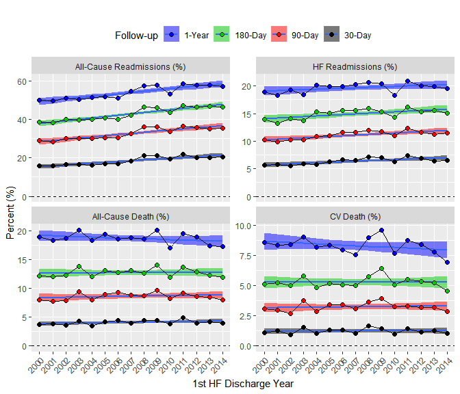

```r
# Save the table as CSV
table1.apx <- cbind.data.frame(t1a.apx,
                               t1b.apx[, -1],
                               t1c.apx[, -1],
                               t1d.apx[, -1])
tmp <- data.frame(matrix(c("HF Discharge Year",
                           rep(c("30-Day",
                                 "90-Day",
                                 "180-Day",
                                 "1-Year"),
                               4)),
                         nrow = 1))
colnames(tmp) <- colnames(table1.apx)

table1.apx <- rbind.data.frame(tmp,
                               table1.apx)
colnames(table1.apx) <- c("",
                          "All-Cause Readmissions (%)", "", "", "",
                          "HF Readmissions (%)", "", "", "",
                          "All-Cause Death (%)", "", "", "",
                          "CV Death (%)", "", "", "")

write.csv(table1.apx,
          file = "tmp/table1.apx.csv",
          row.names = FALSE)

# Clean memory
invisible({
  rm(tmp)
  gc()
})

# Plot rates----
t1.apx <- list(t1a.apx[-16, ],
               t1b.apx[-16, ],
               t1c.apx[-16, ],
               t1d.apx[-16, ])

names(t1.apx) <- c("All-Cause Readmissions (%)",
                   "HF Readmissions (%)",
                   "All-Cause Death (%)",
                   "CV Death (%)")

out <- list()
for (i in 1:length(t1.apx)) {
  out[[i]] <- melt.data.table(data = t1.apx[[i]],
                              id.vars = 1,
                              measure.vars = c(2:5),
                              variable.name = "followup",
                              value.name = "rate")
  out[[i]]$endpoint <- names(t1.apx)[[i]]
}

out <- do.call("rbind", out)

# Re-level follow-up
out$followup <- factor(out$followup,
                       levels = rev(levels(out$followup)))

# Endpoint as a factor
out$endpoint <- factor(out$endpoint,
                       levels = names(t1.apx))

# Figure 1: all rates----
p1 <- ggplot(data = out,
             aes(x = `HF Discharge Year`,
                 y = rate,
                 group = followup,
                 fill = followup)) +
  facet_wrap(~ endpoint,
             nrow = 2,
             scales = "free_y") +
  geom_smooth(method = "lm",
              alpha = 0.5) +
  geom_line(size = 0.5) +
  geom_point(size = 2,
             shape = 21) +
  geom_hline(yintercept = 0,
             linetype = "dashed") +
  scale_x_discrete("1st HF Discharge Year",
                   breaks = unique(out$`HF Discharge Year`),
                   labels = unique(out$`HF Discharge Year`)) +
  scale_y_continuous("Percent (%)") +
  ggtitle("") +
  scale_fill_manual(label = c("1-Year",
                              "180-Day",
                              "90-Day",
                              "30-Day"),
                    values = unique(out$followup)) +
  guides(fill = guide_legend(title = "Follow-up")) +
  theme(legend.position = "top",
        axis.text.x = element_text(angle = 45,
                                   hjust = 1),
        plot.title = element_text(hjust = 0))
print(p1)
```

## 5.6 Linear trends of 1-year outcomes

```r
out <- list()
for (i in 1:length(t1.apx)) {
  tmp <- t1.apx[[i]]
  tmp$year <- as.numeric(as.character(tmp$`HF Discharge Year`)) - 2000
  m1 <- lm(`1-Year` ~ year,
           data = tmp)
  s1 <- summary(m1)
  out[[i]] <- data.table(Outcome = names(t1.apx)[[i]],
                         Slope = s1$coefficients[-1, 1],
                         `95% CI` = paste(round(s1$coefficients[-1, 1] -
                                                  1.96*s1$coefficients[-1, 2],
                                                3),
                                          round(s1$coefficients[-1, 1] +
                                                  1.96*s1$coefficients[-1, 2],
                                                3),
                                          sep = " to "),
                         `p-Value` = ifelse(s1$coefficients[-1, 4] >= 0.001,
                                            round(s1$coefficients[-1, 4], 3),
                                            "<0.001"),
                         Significance = ifelse(s1$coefficients[-1, 4] <= 0.05,
                                               ifelse(s1$coefficients[-1, 4] <= 0.01,
                                                      "**",
                                                      "*"), ""))
}
out <- rbindlist(out)
write.csv(out,
          file = "tmp/table2.apx.csv",
          row.names = FALSE)

datatable(data = out,
          caption = "Table: Linear Trends of 1-Year Outcomes",
          class = "cell-border stripe",
          rownames = FALSE,
          options = list(searching = FALSE,
                         pageLength = nrow(out))) %>%
  formatRound(columns = c(2, 4),
              digits = 3)
```

| Outcome | Slope | 95% CI | p-Value | Significance |
| --- | --- | --- | --- | --- |
| All-Cause Readmissions (%) | 0.665178571428571 | 0.463 to 0.867 | &lt;0.001 | ** |
| HF Readmissions (%) | 0.0860714285714282 | -0.003 to 0.176 | 0.082 |  |
| All-Cause Death (%) | -0.0735714285714277 | -0.182 to 0.035 | 0.208 |  |
| CV Death (%) | -0.0513928571428571 | -0.127 to 0.025 | 0.207 |  |

```r
p2 <- p1 +
  ggtitle("") +
  theme(legend.position = "none")

out1 <- copy(out)

out1$Slope <- format(round(out1$Slope,
                           3),
                     digits = 3)

tbl <- tableGrob(out1,
                 rows = NULL)

tiff(filename = "tmp/fig2.tiff",
     height = 8,
     width = 8,
     units = "in",
     res = 600,
     compression = "lzw+p")
grid.arrange(p2,
             tbl,
             ncol = 1,
             heights = c(15, 2, 1))
graphics.off()
```

# 6 Demographics

```r
# Pubication/Table1: Demographics----
# summary(case)
table1 <- data.table(Description = c("Mean Age at First AMI Admission +/- S.D",
                                     "Male (%)",
                                     "Race (%)",
                                     "* White",
                                     "* Black",
                                     "* Other",
                                     "Ethnicity (%)",
                                     "* Hispanic",
                                     "* Non-Hispanic",
                                     "* Unknown",
                                     "Insurance (%)",
                                     "* Commercial",
                                     "* Medicare",
                                     "* Medicaid/Self-Pay/Other",
                                     "Admission Hospital Type (%)",
                                     "* Teaching",
                                     "* Non-Teaching",
                                     "* Unknown",
                                     "Admission to Hospital Area (%)",
                                     "* Urban",
                                     "* Inner city",
                                     "* Rural",
                                     "* Suburb",
                                     "* Unknown",
                                     "Admission Hospital Cath Lab",
                                     "* Cath Lab",
                                     "* No Cath Lab",
                                     "* Unknown",
                                     "Number of HF Patients"),
                     `Number of Patients` = c(paste(round(mean(case$AGE), 1),
                                                    "+/-",
                                                    round(sd(case$AGE), 1),
                                                    sep = ""),
                                              format(sum(case$SEX == "M"),
                                                     big.mark = ","),
                                              "",
                                              format(sum(case$RACE == "White"),
                                                     big.mark = ","),
                                              format(sum(case$RACE == "Black"),
                                                     big.mark = ","),
                                              format(sum(case$RACE == "Other"),
                                                     big.mark = ","),
                                              "",
                                              format(sum(case$HISPAN == "Hispanic"),
                                                     big.mark = ","),
                                              format(sum(case$HISPAN == "Non-Hispanic"),
                                                     big.mark = ","),
                                              format(sum(case$HISPAN == "Unknown"),
                                                     big.mark = ","),
                                              "",
                                              format(sum(case$PRIME == "COMMERCIAL"),
                                                     big.mark = ","),
                                              format(sum(case$PRIME == "medicare"),
                                                     big.mark = ","),
                                              format(sum(case$PRIME == "medicaid/self-pay/other"),
                                                     big.mark = ","),
                                              "",
                                              format(sum(case$Teach == "Teaching"),
                                                     big.mark = ","),
                                              format(sum(case$Teach == "Non-Teaching"),
                                                     big.mark = ","),
                                              format(sum(case$Teach == "Unknown"),
                                                     big.mark = ","),
                                              "",
                                              format(sum(case$Area == "Urban"),
                                                     big.mark = ","),
                                              format(sum(case$Area == "Inner city"),
                                                     big.mark = ","),
                                              format(sum(case$Area == "Rural"),
                                                     big.mark = ","),
                                              format(sum(case$Area == "Suburb"),
                                                     big.mark = ","),
                                              format(sum(case$Area == "Unknown"),
                                                     big.mark = ","),
                                              "",
                                              format(sum(case$CLAB == "Cath Lab"),
                                                     big.mark = ","),
                                              format(sum(case$CLAB == "No Cath Lab"),
                                                     big.mark = ","),
                                              format(sum(case$CLAB == "Unknown"),
                                                     big.mark = ","),
                                              format(nrow(case),
                                                     big.mark = ",")),
                     `Percent Patients` = c("",
                                            round(100*sum(case$SEX == "F")/nrow(case),
                                                  1),
                                            "",
                                            round(100*sum(case$RACE == "White")/nrow(case),
                                                  1),
                                            round(100*sum(case$RACE == "Black")/nrow(case),
                                                  1),
                                            round(100*sum(case$RACE == "Other")/nrow(case),
                                                  1),
                                            "",
                                            round(100*sum(case$HISPAN == "Hispanic")/nrow(case),
                                                  1),
                                            round(100*sum(case$HISPAN == "Non-Hispanic")/nrow(case),
                                                  1),
                                            round(100*sum(case$HISPAN == "Unknown")/nrow(case),
                                                  1),
                                            "",
                                            round(100*sum(case$PRIME == "COMMERCIAL")/nrow(case),
                                                  1),
                                            round(100*sum(case$PRIME == "medicare")/nrow(case),
                                                  1),
                                            round(100*sum(case$PRIME == "medicaid/self-pay/other")/nrow(case),
                                                  1),
                                            "",
                                            round(100*sum(case$Teach == "Teaching")/nrow(case),
                                                  1),
                                            round(100*sum(case$Teach == "Non-Teaching")/nrow(case),
                                                  1),
                                            round(100*sum(case$Teach == "Unknown")/nrow(case),
                                                  1),
                                            "",
                                            round(100*sum(case$Area == "Urban")/nrow(case),
                                                  1),
                                            round(100*sum(case$Area == "Inner city")/nrow(case),
                                                  1),
                                            round(100*sum(case$Area == "Rural")/nrow(case),
                                                  1),
                                            round(100*sum(case$Area == "Suburb")/nrow(case),
                                                  1),
                                            round(100*sum(case$Area == "Unknown")/nrow(case),
                                                  1),
                                            "",
                                            round(100*sum(case$CLAB == "Cath Lab")/nrow(case),
                                                  1),
                                            round(100*sum(case$CLAB == "No Cath Lab")/nrow(case),
                                                  1),
                                            round(100*sum(case$CLAB == "Unknown")/nrow(case),
                                                  1),
                                            ""))

# Save Table1 as CSV
write.csv(table1,
          file = "tmp/table2.csv",
          row.names = FALSE)

datatable(table1,
          caption = "Table 2: HF patients' characteristics",
          rownames = FALSE,
          class = "cell-border stripe",
          options = list(searching = FALSE,
                         pageLength = nrow(table1)))
```

[output not shown]

[output cut: 19 more lines]

```r
case$readm1y <- case$hf1y <- case$dead1y <- case$cvdeath1y <- FALSE

case$readm1y[case$days2readm < 366] <- TRUE
case$hf1y[case$days2post.hf.dx1 < 366] <- TRUE
case$dead1y[case$days2death < 366] <- TRUE
case$cvdeath1y[case$days2cvdeath < 366] <- TRUE
```

# 7 1-year outcomes vs. demographics

```r
case$SEX <- factor(case$SEX,
                   levels = c("F",
                              "M"))
m1a.1y <- glm(readm1y ~ decade +
                SEX +
                RACE +
                HISPAN +
                PRIME,
              family = binomial(logit),
              data = case)

m1b.1y <- glm(hf1y ~ decade +
                SEX +
                RACE +
                HISPAN +
                PRIME,
              family = binomial(logit),
              data = case)

m1c.1y <- glm(dead1y ~ decade +
                SEX +
                RACE +
                HISPAN +
                PRIME,
              family = binomial(logit),
              data = case)

m1d.1y <- glm(cvdeath1y ~ decade +
                SEX +
                RACE +
                HISPAN +
                PRIME,
              family = binomial(logit),
              data = case)

s1 <- list(summary(m1a.1y),
           summary(m1b.1y),
           summary(m1c.1y),
           summary(m1d.1y))

outcomes <- c("All-Cause Readmission",
              "HF Readmission",
              "All-Cause Death",
              "CV Death")

t1 <- list()
for (i in 1:4) {
  a <- s1[[i]]
  out <- data.table(Row = rownames(a$coefficients)[-1],
                    Covariate = c("Age (x10)",
                                  "Male vs. Female",
                                  "Race:Black vs. White",
                                  "Race:Other vs.White",
                                  "Ethnisity:Non-Hispanic vs. Hispanic",
                                  "Ethnisity:Unknown vs. Hispanic",
                                  "Insurance:Commercial vs. Medicare",
                                  "Insurance:Medicaid/Self-Pay/Other vs. Medicare"),
                    OR = exp(a$coefficients[-1, 1]),
                    `95% C.I.L.B.` = exp(a$coefficients[-1, 1] - 1.96*a$coefficients[-1, 2]),
                    `95% C.I.U.B.` = exp(a$coefficients[-1, 1] + 1.96*a$coefficients[-1, 2]),
                    `p-Value` = ifelse(a$coefficients[-1, 4] >= 0.001,
                                       round(a$coefficients[-1, 4], 3),
                                       "<0.001"),
                    sign = ifelse(a$coefficients[-1, 4] <= 0.05,
                                  ifelse(a$coefficients[-1, 4] <= 0.01,
                                         "**",
                                         "*"), ""))
  print(datatable(data = out,
            caption = paste("Table: Logistic Regression Models of 1-year ",
                            outcomes[i],
                            " vs. Demographics"),
            class = "cell-border stripe",
            rownames = FALSE,
            options = list(searching = FALSE,
                           pageLength = nrow(out))) %>%
    formatRound(columns = 3:5,
                digits = 3))
}
```

| Row | Covariate | OR | 95% C.I.L.B. | 95% C.I.U.B. | p-Value | sign |
| --- | --- | --- | --- | --- | --- | --- |
| decade | Age (x10) | 0.983891268981385 | 0.973354195388965 | 0.994542411964391 | 0.003 | ** |
| SEXM | Male vs. Female | 0.982303139534951 | 0.956437590077818 | 1.0088681874807 | 0.19 |  |
| RACEBlack | Race:Black vs. White | 1.19351746648336 | 1.14901509283948 | 1.23974345652905 | &lt;0.001 | ** |
| RACEOther | Race:Other vs.White | 0.944582906923277 | 0.90399688627435 | 0.986991085476866 | 0.011 | * |
| HISPANNon-Hispanic | Ethnisity:Non-Hispanic vs. Hispanic | 0.843481060975529 | 0.80348231514321 | 0.885471013879871 | &lt;0.001 | ** |
| HISPANUnknown | Ethnisity:Unknown vs. Hispanic | 0.758057277884367 | 0.712340614939985 | 0.806707949120478 | &lt;0.001 | ** |
| PRIMECOMMERCIAL | Insurance:Commercial vs. Medicare | 0.810487024031068 | 0.783564534408362 | 0.838334543329896 | &lt;0.001 | ** |
| PRIMEmedicaid/self-pay/other | Insurance:Medicaid/Self-Pay/Other vs. Medicare | 0.803872603441712 | 0.760110707233508 | 0.8501540057449 | &lt;0.001 | ** |

| Row | Covariate | OR | 95% C.I.L.B. | 95% C.I.U.B. | p-Value | sign |
| --- | --- | --- | --- | --- | --- | --- |
| decade | Age (x10) | 0.996741609872083 | 0.98335357770186 | 1.01031191565116 | 0.636 |  |
| SEXM | Male vs. Female | 1.08985531047642 | 1.05396209272493 | 1.1269708901036 | &lt;0.001 | ** |
| RACEBlack | Race:Black vs. White | 1.32011616303501 | 1.26134587365452 | 1.38162475519669 | &lt;0.001 | ** |
| RACEOther | Race:Other vs.White | 0.978895314987143 | 0.925720408794419 | 1.03512467544245 | 0.454 |  |
| HISPANNon-Hispanic | Ethnisity:Non-Hispanic vs. Hispanic | 0.784236360254618 | 0.740178818269053 | 0.830916332061059 | &lt;0.001 | ** |
| HISPANUnknown | Ethnisity:Unknown vs. Hispanic | 0.71530951823009 | 0.66225962325536 | 0.77260894202706 | &lt;0.001 | ** |
| PRIMECOMMERCIAL | Insurance:Commercial vs. Medicare | 0.86072964343068 | 0.824435852783295 | 0.898621180264271 | &lt;0.001 | ** |
| PRIMEmedicaid/self-pay/other | Insurance:Medicaid/Self-Pay/Other vs. Medicare | 1.08306230688563 | 1.01242355259718 | 1.15862966402476 | 0.02 | * |

| Row | Covariate | OR | 95% C.I.L.B. | 95% C.I.U.B. | p-Value | sign |
| --- | --- | --- | --- | --- | --- | --- |
| decade | Age (x10) | 1.60784681581891 | 1.58143316959942 | 1.63470163193416 | &lt;0.001 | ** |
| SEXM | Male vs. Female | 1.13472642451949 | 1.09525389081608 | 1.17562153332629 | &lt;0.001 | ** |
| RACEBlack | Race:Black vs. White | 0.876760361675569 | 0.828430696187605 | 0.92790952259861 | &lt;0.001 | ** |
| RACEOther | Race:Other vs.White | 0.816718323298236 | 0.766185280044803 | 0.870584226797046 | &lt;0.001 | ** |
| HISPANNon-Hispanic | Ethnisity:Non-Hispanic vs. Hispanic | 1.40449473413313 | 1.3029179184915 | 1.51399058237801 | &lt;0.001 | ** |
| HISPANUnknown | Ethnisity:Unknown vs. Hispanic | 1.36091366822337 | 1.24203740262492 | 1.49116766406793 | &lt;0.001 | ** |
| PRIMECOMMERCIAL | Insurance:Commercial vs. Medicare | 0.768305785106466 | 0.732229755424399 | 0.806159234932935 | &lt;0.001 | ** |
| PRIMEmedicaid/self-pay/other | Insurance:Medicaid/Self-Pay/Other vs. Medicare | 0.833279621296307 | 0.756974094163509 | 0.917277001447467 | &lt;0.001 | ** |

| Row | Covariate | OR | 95% C.I.L.B. | 95% C.I.U.B. | p-Value | sign |
| --- | --- | --- | --- | --- | --- | --- |
| decade | Age (x10) | 1.54146315312397 | 1.50629474549348 | 1.57745265961241 | &lt;0.001 | ** |
| SEXM | Male vs. Female | 1.15312803257956 | 1.09804042076487 | 1.21097933589236 | &lt;0.001 | ** |
| RACEBlack | Race:Black vs. White | 0.89172049964337 | 0.822658892678466 | 0.966579777549442 | 0.005 | ** |
| RACEOther | Race:Other vs.White | 0.887164923866149 | 0.811821079972982 | 0.969501311994294 | 0.008 | ** |
| HISPANNon-Hispanic | Ethnisity:Non-Hispanic vs. Hispanic | 1.37696618826661 | 1.23654895059773 | 1.53332861001011 | &lt;0.001 | ** |
| HISPANUnknown | Ethnisity:Unknown vs. Hispanic | 1.34012233692509 | 1.1772638250057 | 1.52551011912463 | &lt;0.001 | ** |
| PRIMECOMMERCIAL | Insurance:Commercial vs. Medicare | 0.7775196172015 | 0.726062027547826 | 0.832624117769809 | &lt;0.001 | ** |
| PRIMEmedicaid/self-pay/other | Insurance:Medicaid/Self-Pay/Other vs. Medicare | 0.810144671816992 | 0.70390930263521 | 0.932413290769644 | 0.003 | ** |

# 8 Length of stay

```r
# Length of stay
case$los <- as.numeric(difftime(case$DSCHDAT,
                                case$ADMDAT,
                                units = "days"))
sum(case$los == 0)
```

```
[1] 3433
```

```r
# Distribution of length of stay
summary(case$los)
```

```
   Min. 1st Qu.  Median    Mean 3rd Qu.    Max.
  0.000   3.000   4.000   5.709   7.000 289.000
```

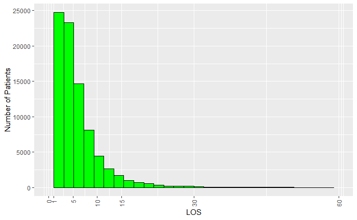

```r
p1 <- ggplot(case[ , "los"],
             aes(x = los)) +
  geom_histogram(bins = 30,
                 color = "black",
                 fill = "green") +
  scale_x_continuous("LOS",
                     limits = c(0, 60),
                     breaks = c(0, 1, 5, 10, 15, 30, 60, 120, 180)) +
  scale_y_continuous("Number of Patients") +
  theme(axis.text.x = element_text(angle = 90,
                                   vjust = 0.5,
                                   hjust = 1))
p1
```

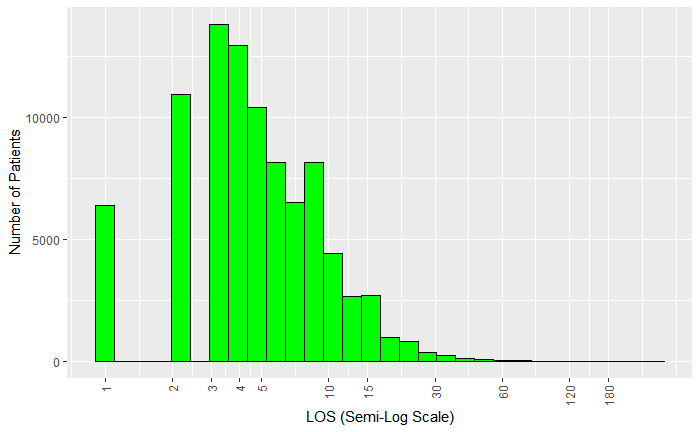

```r
p2 <- ggplot(case[ , "los"],
             aes(x = los)) +
  geom_histogram(bins = 30,
                 color = "black",
                 fill = "green") +
  scale_x_log10("LOS (Semi-Log Scale)",
                breaks = c(0:5, 10, 15, 30, 60, 120, 180)) +
  scale_y_continuous("Number of Patients") +
  theme(axis.text.x = element_text(angle = 90,
                                   vjust = 0.5,
                                   hjust = 1))
p2
```

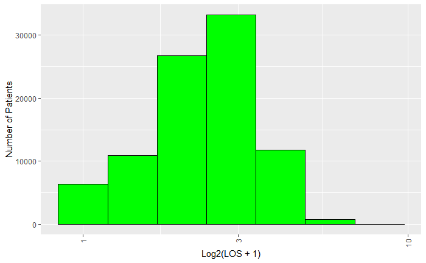

```r
p3 <- ggplot(case[ , "los"],
             aes(x = log2(los + 1))) +
  geom_histogram(bins = 7,
                 color = "black",
                 fill = "green") +
  scale_x_log10("Log2(LOS + 1)") +
  scale_y_continuous("Number of Patients") +
  theme(axis.text.x = element_text(angle = 90,
                                   vjust = 0.5,
                                   hjust = 1))
p3
```

**NOTE***: 3,433 patients were discharged at the day of admission. This might include transfers to other hospitals but we did not look at transfers.

```r
m1a.1y <- glm(readm1y ~ log2(los + 1),
              family = binomial(logit),
              data = case)
m1b.1y <- glm(hf1y ~ log2(los + 1),
              family = binomial(logit),
              data = case)
m1c.1y <- glm(dead1y ~ log2(los + 1),
              family = binomial(logit),
              data = case)
m1d.1y <- glm(cvdeath1y ~ log2(los + 1),
              family = binomial(logit),
              data = case)

s1 <- list(summary(m1a.1y),
           summary(m1b.1y),
           summary(m1c.1y),
           summary(m1d.1y))

t1 <- list()
t1 <- lapply(s1, function(a) {
  out <- data.table(Outcome = "",
                    OR = exp(a$coefficients[-1, 1]),
                    `95% C.I.L.B.` = exp(a$coefficients[-1, 1] - 1.96*a$coefficients[-1, 2]),
                    `95% C.I.U.B.` = exp(a$coefficients[-1, 1] + 1.96*a$coefficients[-1, 2]),
                    `p-Value` = ifelse(a$coefficients[-1, 4] >= 0.001,
                                       round(a$coefficients[-1, 4], 3),
                                       "<0.001"),
                    sign = ifelse(a$coefficients[-1, 4] <= 0.05,
                                  ifelse(a$coefficients[-1, 4] <= 0.01,
                                         "**",
                                         "*"), ""))
  rownames(out) <- NULL
  return(out)
})

t1 <- do.call("rbind", t1)
t1$Outcome <- c("All-Cause Readmission",
                "HF Readmission",
                "All-Cause Death",
                "CV Death")

datatable(data = t1,
          caption = "Logistic Regression Models of 1-year Outcomes vs. Log2(LOS + 1)",
          class = "cell-border stripe",
          rownames = FALSE,
          options = list(searching = FALSE,
                         pageLength = nrow(t1))) %>%
  formatRound(columns = 2:4,
              digits = 3)
```

| Outcome | OR | 95% C.I.L.B. | 95% C.I.U.B. | p-Value | sign |
| --- | --- | --- | --- | --- | --- |
| All-Cause Readmission | 1.06558272285218 | 1.05123731323855 | 1.08012389299904 | &lt;0.001 | ** |
| HF Readmission | 1.04172713480447 | 1.02413740115655 | 1.05961897511255 | &lt;0.001 | ** |
| All-Cause Death | 1.52292618473259 | 1.49550126052817 | 1.55085403493745 | &lt;0.001 | ** |
| CV Death | 1.37836404453007 | 1.34462967120101 | 1.41294475344749 | &lt;0.001 | ** |

# 9 Causes of readmission

```r
source("source/icd9_dx_get_data_v1.R")
dt.icd <- icd9cm_merge_version_dx(32)

map <- unique(data.table(readm.dx1 = dt.icd$code,
                         major = dt.icd$major))

tmp <- case[readm == TRUE,
            c("Patient_ID",
              "readm.dx1",
              "days2readm")]
tmp <- merge(map,
             tmp,
             by = "readm.dx1")
readm_cause <- copy(tmp)

tmp30 <- tmp[days2readm < 31, ]
t30 <- data.table(table(tmp30$major))
t30$Percent <- round(100*t30$N/sum(t30$N), 1)
t30 <- t30[order(t30$N,
                 decreasing = TRUE),]
t30$N <- format(t30$N,
                big.mark = ",")
datatable(t30,
          caption = "30-Day Readmissions by Cause (DX1)",
          class = "cell-border stripe",
          rownames = FALSE,
          options = list(searching = TRUE,
                         pageLength = 20))
```

| V1 | N | Percent |
| --- | --- | --- |
| Heart failure | 4,262 | 25.5 |
| Other forms of chronic ischemic heart disease | 1,076 | 6.4 |
| Cardiac dysrhythmias | 845 | 5.1 |
| Symptoms involving respiratory system and other chest symptoms | 506 | 3 |
| Acute kidney failure | 483 | 2.9 |
| Pneumonia, organism unspecified | 439 | 2.6 |
| Acute myocardial infarction | 433 | 2.6 |
| Other diseases of endocardium | 386 | 2.3 |
| General symptoms | 369 | 2.2 |
| Diabetes mellitus | 355 | 2.1 |

[output cut: 365 more lines]

```r
tmp90<- tmp[days2readm < 91, ]
t90 <- data.table(table(tmp90$major))
t90$Percent <- round(100*t90$N/sum(t90$N), 1)
t90 <- t90[order(t90$N,
                 decreasing = TRUE),]
t90$N <- format(t90$N,
                big.mark = ",")
datatable(t90,
          caption = "90-Day Readmissions by Cause (DX1)",
          class = "cell-border stripe",
          rownames = FALSE,
          options = list(searching = TRUE,
                         pageLength = 20))
```

| V1 | N | Percent |
| --- | --- | --- |
| Heart failure | 7,495 | 25.3 |
| Other forms of chronic ischemic heart disease | 1,843 | 6.2 |
| Cardiac dysrhythmias | 1,553 | 5.2 |
| Symptoms involving respiratory system and other chest symptoms | 846 | 2.9 |
| Pneumonia, organism unspecified | 791 | 2.7 |
| Acute myocardial infarction | 790 | 2.7 |
| Acute kidney failure | 770 | 2.6 |
| Diabetes mellitus | 669 | 2.3 |
| General symptoms | 632 | 2.1 |
| Other diseases of endocardium | 576 | 1.9 |

[output cut: 437 more lines]

```r
tmp180 <- tmp[days2readm < 181, ]
t180 <- data.table(table(tmp180$major))
t180$Percent <- round(100*t180$N/sum(t180$N), 1)
t180 <- t180[order(t180$N,
                   decreasing = TRUE),]
t180$N <- format(t180$N,
                 big.mark = ",")
datatable(t180,
          caption = "180-Day Readmissions by Cause (DX1)",
          class = "cell-border stripe",
          rownames = FALSE,
          options = list(searching = TRUE,
                         pageLength = 20))
```

| V1 | N | Percent |
| --- | --- | --- |
| Heart failure | 9,550 | 24.5 |
| Other forms of chronic ischemic heart disease | 2,295 | 5.9 |
| Cardiac dysrhythmias | 2,037 | 5.2 |
| Symptoms involving respiratory system and other chest symptoms | 1,210 | 3.1 |
| Acute myocardial infarction | 1,054 | 2.7 |
| Pneumonia, organism unspecified | 1,049 | 2.7 |
| Acute kidney failure | 943 | 2.4 |
| Diabetes mellitus | 931 | 2.4 |
| General symptoms | 856 | 2.2 |
| Septicemia | 683 | 1.8 |

[output cut: 467 more lines]

```r
tmp1y <- tmp[days2readm < 366, ]
t1y <- data.table(table(tmp1y$major))
t1y$Percent <- round(100*t1y$N/sum(t1y$N), 1)
t1y <- t1y[order(t1y$N,
                 decreasing = TRUE),]
t1y$N <- format(t1y$N,
                big.mark = ",")
datatable(t1y,
          caption = "1-Year Readmissions by Cause (DX1)",
          class = "cell-border stripe",
          rownames = FALSE,
          options = list(searching = TRUE,
                         pageLength = 20))
```

| V1 | N | Percent |
| --- | --- | --- |
| Heart failure | 11,617 | 23.6 |
| Other forms of chronic ischemic heart disease | 2,659 | 5.4 |
| Cardiac dysrhythmias | 2,535 | 5.1 |
| Symptoms involving respiratory system and other chest symptoms | 1,565 | 3.2 |
| Pneumonia, organism unspecified | 1,413 | 2.9 |
| Acute myocardial infarction | 1,370 | 2.8 |
| Diabetes mellitus | 1,161 | 2.4 |
| General symptoms | 1,154 | 2.3 |
| Acute kidney failure | 1,133 | 2.3 |
| Chronic bronchitis | 913 | 1.9 |

[output cut: 498 more lines]

# 10 Group top reasons for readmission

Reasons for readmission present in at least 1% of patients at 1 year (21 in total) were grouped into 12 categories as the following:

```r
# Readmission causes, groupped by Mike and Dr. Kostis
readm_grp <- fread("data/HF readmissions by cause.csv")
setkey(readm_grp,
       group)

datatable(readm_grp,
          caption = "Table: grouping of reasons for redmission",
          class = "cell-border stripe",
          rownames = FALSE,
          options = list(searching = TRUE,
                         pageLength = nrow(readm_grp)))
```

| major | group |
| --- | --- |
| Acute myocardial infarction | AMI |
| Cardiac dysrhythmias | Arrhythmia |
| Occlusion of cerebral arteries | Cerebrovascular |
| Diabetes mellitus | Diabetes mellitus |
| General symptoms | General symptoms |
| Other forms of chronic ischemic heart disease | Heart Disease |
| Other diseases of endocardium | Heart Disease |
| Heart failure | Heart failure |
| Hypertensive heart disease | Hypertension |
| Hypertensive heart and chronic kidney disease | Hypertension |

[output cut: 11 more lines]

```r
readm1y <- merge(readm_grp,
                 tmp1y,
                 by = "major")
readm1y$days2readm <- NULL
readm1y$readm.dx1 <- NULL

case2 <- merge(case,
               readm1y,
               by = "Patient_ID",
               all.x = TRUE)

case2$group[is.na(case2$group)] <- "Other Reason"
case2$group[case2$days2readm > 365 |
              is.na(case2$days2readm)] <- "Not Readmitted"

case2$group <- factor(case2$group,
                      levels = c("Heart failure",
                                 "AMI",
                                 "Heart Disease",
                                 "Respiratory",
                                 "Kidney Disease",
                                 "Arrhythmia",
                                 "Infections",
                                 "Diabetes mellitus",
                                 "General symptoms",
                                 "Hypertension",
                                 "Procedures",
                                 "Cerebrovascular",
                                 "Other Reason",
                                 "Not Readmitted"))

case2$readm1y <- case2$group != "Not Readmitted"
```

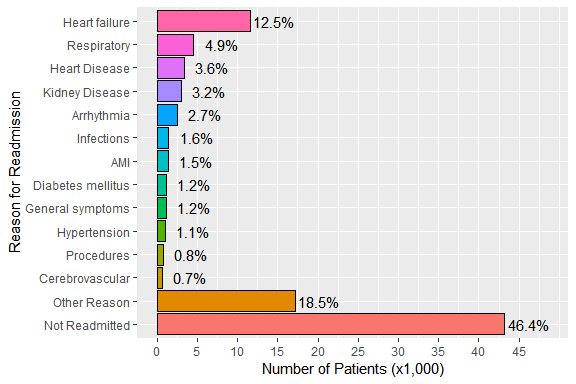

```r
t1yg <- data.table(table(case2$group))
t1yg$Percent <- round(100*t1yg$N/sum(t1yg$N), 1)
t1yg$V1 <- factor(t1yg$V1,
                  levels = c("Not Readmitted",
                             "Other Reason",
                             "Cerebrovascular",
                             "Procedures",
                             "Hypertension",
                             "General symptoms",
                             "Diabetes mellitus",
                             "AMI",
                             "Infections",
                             "Arrhythmia",
                             "Kidney Disease",
                             "Heart Disease",
                             "Respiratory",
                             "Heart failure"))

p1 <- ggplot(t1yg,
             aes(x = V1,
                 y = N,
                 fill = V1)) +
  coord_flip() +
  geom_bar(stat = "identity",
           position = position_dodge(0.9),
           color = "black") +
  scale_x_discrete("Reason for Readmission") +
  scale_y_continuous("Number of Patients (x1,000)",
                     breaks = seq(0, 45000, by = 5000),
                     labels = seq(0, 45, by = 5)) +
  geom_text(aes(x = V1,
                y = N + 5500,
                angle = 0,
                label = paste(Percent,
                              "%",
                              sep = "")),
            hjust = 1,
            size = 4,
            position = position_dodge(0.9)) +
  theme(legend.position = "none")

# Save for publication
tiff(filename = "tmp/fig3.tiff",
     height = 4,
     width = 6,
     units = "in",
     res = 600,
     compression = "lzw+p")
print(p1)
graphics.off()

p1
```

# 11 Distribution of days to readmission within 1 year by reason

```r
summary(case2$days2readm)
```

```
   Min. 1st Qu.  Median    Mean 3rd Qu.    Max.    NA's
    1.0    32.0   131.0   362.2   434.0  5550.0   23190
```

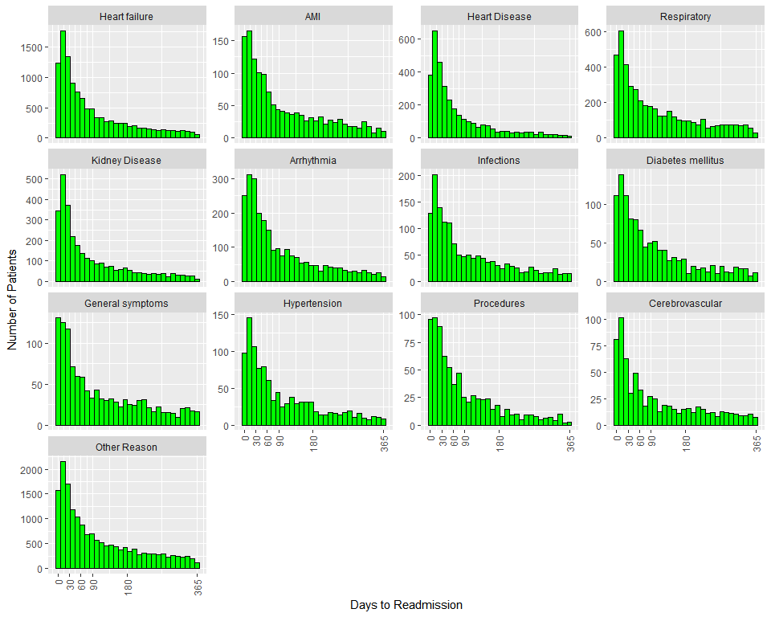

```r
p1 <- ggplot(case2[readm1y == TRUE, ],
             aes(x = days2readm)) +
  facet_wrap(~ group,
             scale = "free_y") +
  geom_histogram(color = "black",
                 fill = "green",
                 bins = 30) +
  scale_x_continuous("Days to Readmission",
                     breaks = c(0, 30, 60, 90, 180, 365)) +
  scale_y_continuous("Number of Patients") +
  theme(axis.text.x = element_text(angle = 90,
                                   hjust = 1,
                                   vjust = 0.5))
p1
```

# 12 Effect of Hospital Readmissions Reduction Program (HRRP)

[Hospital Readmissions Reduction Program (HRRP)](https://www.cms.gov/medicare/medicare-fee-for-service-payment/acuteinpatientpps/readmissions-reduction-program.html) was implemented beginning October 1, 2012 (i.e., Federal Fiscal Year 2013). Additionally, the 21st Century Cures Act required CMS to assess penalties based on a hospital’s performance relative to other hospitals with a similar proportion of patients who are dually eligible for Medicare and full-benefit Medicaid beginning in FY 2019. We hypothesized that this program resulted in reduced number of recorded HF readmissions.

```r
tmp1 <- data.table(readm.hf = (case2$group == "Heart failure"),
                   days2readm = case2$days2readm,
                   dsch.year = case2$DSCYR)

tmp1[, readm30 := days2readm < 31]
tmp1$readm30[is.na(tmp1$readm30)] <- FALSE

t5 <- addmargins(table(dsch.year = tmp1$dsch.year,
                       readm.hf = tmp1$readm.hf,
                       readm30 = tmp1$readm30))
tt1 <- data.table(dsch.year = rownames(t5[, , 1]),
                  n.readm.hf.30d = t5[, 2, 2],
                  n.readm.hf.1y = t5[, 2, 3],
                  n.hf = t5[, 3, 3])

tt2 <- data.table(`Discharge Year` = tt1$dsch.year,
                  `30-Day HF Readmission (%)` = 100*tt1$n.readm.hf.30d/tt1$n.hf,
                  `1-Year HF Readmission (%)` = 100*tt1$n.readm.hf.1y/tt1$n.hf,
                  `Number of HF Patients` = tt1$n.hf)

datatable(data = tt2,
          caption = "30-day and 1-year HF readmission rates",
          class = "cell-border stripe",
          rownames = FALSE,
          options = list(searching = TRUE,
                         pageLength = nrow(tt2))) %>%
  formatRound(columns = 2:3,
              digits = 1) %>%
    formatCurrency(columns = 4,
                 currency = "",
                 digits = 0,
                 mark = ",")
```

| Discharge Year | 30-Day HF Readmission (%) | 1-Year HF Readmission (%) | Number of HF Patients |
| --- | --- | --- | --- |
| 2000 | 4.29123711340206 | 12.680412371134 | 7760 |
| 2001 | 3.94826412525528 | 11.7086453369639 | 7345 |
| 2002 | 4.00220052262412 | 12.5567322239032 | 7271 |
| 2003 | 4.42748091603053 | 12.616238723109 | 7205 |
| 2004 | 4.13184772516249 | 13.107397090684 | 6462 |
| 2005 | 4.38568203805224 | 12.7539503386005 | 6202 |
| 2006 | 4.80069324090121 | 13.1889081455806 | 5770 |
| 2007 | 4.59221160911095 | 12.8581925055107 | 5444 |
| 2008 | 5.29472241261138 | 12.8341329677862 | 5836 |
| 2009 | 5.14225128114508 | 12.6877540201449 | 5659 |

[output cut: 6 more lines]

No reduction in 30-day HF readmission rates was observed.

# 13 1-year mortality vs. days to readmission within 1 year

```r
dtreadm <- droplevels(case[!is.na(days2readm), ])
summary(dtreadm$days2readm)
```

```
   Min. 1st Qu.  Median    Mean 3rd Qu.    Max.
    1.0    32.0   131.0   362.2   434.0  5550.0
```

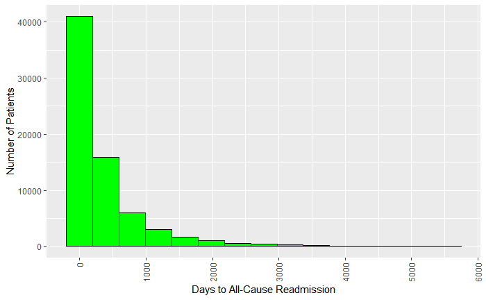

```r
p1 <- ggplot(dtreadm,
             aes(x = days2readm)) +
  geom_histogram(bins = 15,
                 color = "black",
                 fill = "green") +
  scale_x_continuous("Days to All-Cause Readmission",
                     breaks = seq(0, 6000, by = 1000)) +
  scale_y_continuous("Number of Patients") +
  theme(axis.text.x = element_text(angle = 90,
                                   vjust = 0.5,
                                   hjust = 1))
p1
```

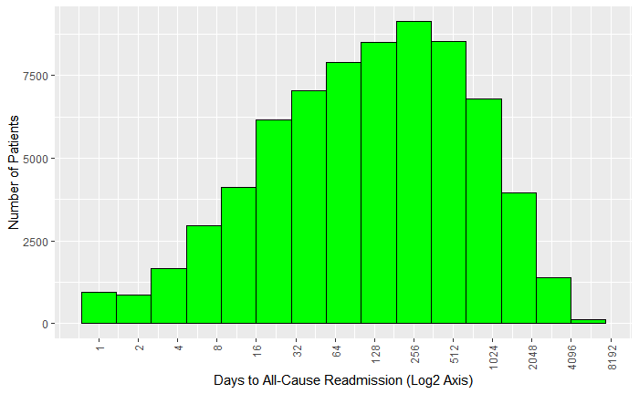

```r
p2 <- ggplot(dtreadm,
             aes(x = log2(days2readm))) +
  geom_histogram(bins = 15,
                 color = "black",
                 fill = "green") +
  scale_x_continuous("Days to All-Cause Readmission (Log2 Axis)",
                     breaks = 0:15,
                     labels = 2^(0:15)) +
  scale_y_continuous("Number of Patients") +
  theme(axis.text.x = element_text(angle = 90,
                                   vjust = 0.5,
                                   hjust = 1))
p2
```

```r
m1c.1y <- glm(dead1y ~ log2(days2readm),
              family = binomial(logit),
              data = dtreadm)

s1 <- summary(m1c.1y)

t1 <- data.table(Outcome = "All-Cause Death",
                 OR = exp(s1$coefficients[-1, 1]),
                 `95% C.I.L.B.` = exp(s1$coefficients[-1, 1] - 1.96*s1$coefficients[-1, 2]),
                 `95% C.I.U.B.` = exp(s1$coefficients[-1, 1] + 1.96*s1$coefficients[-1, 2]),
                 `p-Value` = ifelse(s1$coefficients[-1, 4] >= 0.001,
                                    round(s1$coefficients[-1, 4], 3),
                                    "<0.001"),
                 Significance = ifelse(s1$coefficients[-1, 4] <= 0.05,
                               ifelse(s1$coefficients[-1, 4] <= 0.01,
                                      "**",
                                      "*"), ""))
datatable(data = t1,
          caption = "Logistic regression models of log-days to all-cause readmission vs. 1-year all-cause death",
          class = "cell-border stripe",
          rownames = FALSE,
          options = list(searching = FALSE,
                         pageLength = nrow(t1))) %>%
  formatRound(columns = 2:4,
              digits = 3)
```

| Outcome | OR | 95% C.I.L.B. | 95% C.I.U.B. | p-Value | Significance |
| --- | --- | --- | --- | --- | --- |
| All-Cause Death | 0.723027692899913 | 0.716699418814825 | 0.729411844040075 | &lt;0.001 | ** |

# 14 LOS vs. Days to Readmission

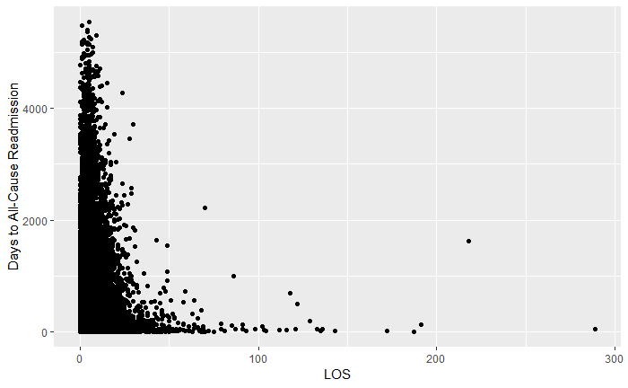

```r
p1 <- ggplot(case,
             aes(y = days2readm,
                 x = los)) +
  geom_point() +
  scale_x_continuous("LOS") +
  scale_y_continuous("Days to All-Cause Readmission")
p1
```

# 15 Full Models

```r
case1 <- copy(case)
case <- droplevels(case[Area != "Unknown", ])

# Remove patients from hosps with no info
paste(format(nrow(case1[Area == "Unknown", ]),
             big.mark = ","),
      "patients are from hospitals with no info; REMOVE THEM!")
```

```
[1] "3,353 patients are from hospitals with no info; REMOVE THEM!"
```

```r
t2.names <- c("Discharge year",
              "Age (X10)",
              "Male vs. Female",
              "Race:Black vs. White",
              "Race:Other vs.White",
              "Ethnisity:Non-Hispanic vs. Hispanic",
              "Ethnisity:Unknown vs. Hispanic",
              "Insurance:Commercial vs. Medicare",
              "Insurance:Medicaid/Self-Pay/Other vs. Medicare",
              "Length of Stay",
              "AFib/AFlutter",
              "AMI",
              "Anemia",
              "CKD",
              "COPD",
              "Diabetes",
              "Hypertension",
              "Hyperlipidemia",
              "Sleep Apnea",
              "Parkinson",
              "Stroke",
              "TIA",
              "Hosp:No Cath Lab vs. Cath Lab",
              # "Hosp:Unknown vs. Cath Lab",
              "Area:Inner City Area vs. Urban",
              "Area:Rural Area vs. Urban",
              "Area:Suburb Area vs. Urban",
              # "Area:Unknown Area vs. Urban",
              "Hosp:Non-Teaching vs. Teaching")
# "Hosp:Unknown vs. Teaching")
```

## 15.1 Correlations of binary variables

See Appendix, Statistics section for details.

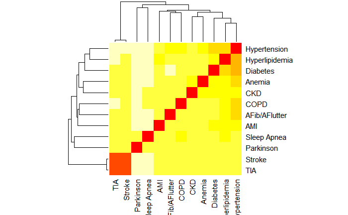

```r
tmp <- case[, haf:htia]
colnames(tmp) <- c("AFib/AFlutter",
                   "AMI",
                   "Anemia",
                   "CKD",
                   "COPD",
                   "Diabetes",
                   "Hypertension",
                   "Hyperlipidemia",
                   "Sleep Apnea",
                   "Parkinson",
                   "Stroke",
                   "TIA")
cor1 <- cor(tmp,
            use = "pairwise.complete.obs")
heatmap(cor1,
        col = rev(heat.colors(10)))
```

Stroke and TIA are highly correlated while hypertension is mildley correlated with hyperlipidemia, diabetes, COPD and AFib/AFlutter.

## 15.2 All-Cause Readmissions

```r
case$readm30 <- case$readm90 <- case$readm180 <- case$readm1y <- FALSE
case$readm30[case$days2readm < 31] <- TRUE
case$readm90[case$days2readm < 91] <- TRUE
case$readm180[case$days2readm < 181] <- TRUE
case$readm1y[case$days2readm < 366] <- TRUE

m2a.30 <- glm(readm30 ~ DSCYR +
                decade +
                SEX +
                RACE +
                HISPAN +
                PRIME +
                log2(los + 1) +
                haf +
                hami +
                hanemia  +
                hckd +
                hcopd +
                hdiab +
                hhyper +
                hlipid  +
                hosa +
                hpark +
                hstroke  +
                htia +
                CLAB +
                Area +
                Teach,
              family = binomial(logit),
              data = case)

m2a.90 <- glm(readm90 ~ DSCYR +
                decade +
                SEX +
                RACE +
                HISPAN +
                PRIME +
                log2(los + 1) +
                haf +
                hami +
                hanemia  +
                hckd +
                hcopd +
                hdiab +
                hhyper +
                hlipid  +
                hosa +
                hpark +
                hstroke  +
                htia +
                CLAB +
                Area +
                Teach,
              family = binomial(logit),
              data = case)

m2a.180 <- glm(readm180 ~ DSCYR +
                 decade +
                 SEX +
                 RACE +
                 HISPAN +
                 PRIME +
                 log2(los + 1) +
                 haf +
                 hami +
                 hanemia  +
                 hckd +
                 hcopd +
                 hdiab +
                 hhyper +
                 hlipid  +
                 hosa +
                 hpark +
                 hstroke  +
                 htia +
                 CLAB +
                 Area +
                 Teach,
               family = binomial(logit),
               data = case)

m2a.1y <- glm(readm1y ~ DSCYR +
                decade +
                SEX +
                RACE +
                HISPAN +
                PRIME +
                log2(los + 1) +
                haf +
                hami +
                hanemia  +
                hckd +
                hcopd +
                hdiab +
                hhyper +
                hlipid  +
                hosa +
                hpark +
                hstroke  +
                htia +
                CLAB +
                Area +
                Teach,
              family = binomial(logit),
              data = case)

# Combine
s2a <- list(summary(m2a.30),
            summary(m2a.90),
            summary(m2a.180),
            summary(m2a.1y))

t2a <- lapply(s2a, function(a) {
  out <- data.table(Level = rownames(a$coefficients)[-1],
                    names = t2.names,
                    coef = exp(a$coefficients[-1, 1]),
                    lb = exp(a$coefficients[-1, 1] - 1.96*a$coefficients[-1, 2]),
                    ub = exp(a$coefficients[-1, 1] + 1.96*a$coefficients[-1, 2]),
                    pval = ifelse(a$coefficients[-1, 4] >= 0.001,
                                  format(round(a$coefficients[-1, 4],
                                               3),
                                         digits = 3),
                                  "<0.001"),
                    sign = ifelse(a$coefficients[-1, 4] <= 0.05,
                                  ifelse(a$coefficients[-1, 4] <= 0.01,
                                         "**",
                                         "*"), ""))
  rownames(out) <- NULL
  return(out)
})

t2a <- do.call("rbind", t2a)

t2a <- data.table(followup = rep(c("30-Day",
                                   "90-Day",
                                   "180-Day",
                                   "1-Year"),
                                 each = length(t2.names)),
                  t2a)
t2a$names <- factor(t2a$names,
                    levels = unique(t2a$names))
t2a$followup <- factor(as.character(t2a$followup),
                       levels = c("30-Day",
                                  "90-Day",
                                  "180-Day",
                                  "1-Year"))

t2a$clr <- 2
t2a$clr[t2a$lb > 1] <- 1
t2a$clr[t2a$ub < 1] <- 3
t2a$clr <- factor(t2a$clr,
                  levels = 1:3,
                  labels = c("Increased Risk",
                             "No Difference",
                             "Decreased Risk"))

# Save Table 2A as CSV
t2a$est <- paste(round(t2a$coef, 3),
                 " (",
                 round(t2a$lb, 3),
                 ", ",
                 round(t2a$ub, 3),
                 ")\n",
                 t2a$pval,
                 sep = "")
table2a <- dcast.data.table(data = t2a,
                            Level + names ~ followup,
                            value.var = "est")
colnames(table2a)[2] <- "Risk Factor"

write.csv(table2a,
          file = "tmp/table2a.csv",
          row.names = FALSE)

tt1 <- apply(table2a[, -c(1:2)],
             MARGIN = 2,
             function(a) {
               substr(x = a,
                      start = nchar(a) - 4,
                      stop = nchar(a)) %>%
                 as.numeric()
             })
colnames(tt1) <- LETTERS[1:4]

tmp2a <- cbind(table2a,
               tt1)

# Relevels
tmp2a <- tmp2a[order(tmp2a$`30-Day`,
                     decreasing = TRUE), ]
lvls <- tmp2a$`Risk Factor`
tmp2a$`Risk Factor` <- factor(tmp2a$`Risk Factor`,
                              levels = lvls)
t2a$names <- factor(t2a$names,
                    levels = lvls)
write.csv(tmp2a,
          file = "tmp/table3.csv")

datatable(data = tmp2a,
          caption = "Table2A: All-Cause Readmissions",
          class = "cell-border stripe",
          rownames = FALSE,
          options = list(searching = TRUE,
                         pageLength = nrow(table2a),
                         columnDefs = list(list(visible = FALSE,
                                                targets = 6:9)))) %>%
  formatStyle(columns = 3,
              valueColumns = 7,
              color = "black",
              backgroundColor = styleInterval(cuts = c(0.05),
                                              values = c("yellow",
                                                         "white"))) %>%
  formatStyle(columns = 4,
              valueColumns = 8,
              color = "black",
              backgroundColor = styleInterval(cuts = c(0.05),
                                              values = c("yellow",
                                                         "white"))) %>%
  formatStyle(columns = 5,
              valueColumns = 9,
              color = "black",
              backgroundColor = styleInterval(cuts = c(0.05),
                                              values = c("yellow",
                                                         "white"))) %>%
  formatStyle(columns = 6,
              valueColumns = 10,
              color = "black",
              backgroundColor = styleInterval(cuts = c(0.05),
                                              values = c("yellow",
                                                         "white")))
```

| Level | Risk Factor | 30-Day | 90-Day | 180-Day | 1-Year | A | B | C | D |
| --- | --- | --- | --- | --- | --- | --- | --- | --- | --- |
| hckdTRUE | CKD | 1.286 (1.199, 1.379) &lt;0.001 | 1.299 (1.221, 1.382) &lt;0.001 | 1.313 (1.234, 1.398) &lt;0.001 | 1.329 (1.243, 1.42) &lt;0.001 | 0.001 | 0.001 | 0.001 | 0.001 |
| hstrokeTRUE | Stroke | 1.256 (0.979, 1.611) 0.073 | 1.199 (0.962, 1.494) 0.105 | 1.157 (0.931, 1.439) 0.188 | 1.233 (0.979, 1.553) 0.075 | 0.073 | 0.105 | 0.188 | 0.075 |
| hparkTRUE | Parkinson | 1.179 (1.017, 1.366) 0.029 | 1.162 (1.023, 1.321) 0.021 | 1.084 (0.956, 1.229) 0.208 | 1.167 (1.025, 1.328) 0.020 | 0.029 | 0.021 | 0.208 | 0.02 |
| hanemiaTRUE | Anemia | 1.174 (1.119, 1.231) &lt;0.001 | 1.201 (1.153, 1.251) &lt;0.001 | 1.207 (1.159, 1.256) &lt;0.001 | 1.201 (1.153, 1.252) &lt;0.001 | 0.001 | 0.001 | 0.001 | 0.001 |
| hdiabTRUE | Diabetes | 1.164 (1.115, 1.216) &lt;0.001 | 1.201 (1.158, 1.245) &lt;0.001 | 1.245 (1.202, 1.29) &lt;0.001 | 1.293 (1.247, 1.341) &lt;0.001 | 0.001 | 0.001 | 0.001 | 0.001 |
| hhyperTRUE | Hypertension | 1.155 (1.105, 1.208) &lt;0.001 | 1.214 (1.17, 1.26) &lt;0.001 | 1.323 (1.278, 1.37) &lt;0.001 | 1.448 (1.398, 1.499) &lt;0.001 | 0.001 | 0.001 | 0.001 | 0.001 |
| hcopdTRUE | COPD | 1.154 (1.102, 1.209) &lt;0.001 | 1.181 (1.135, 1.228) &lt;0.001 | 1.226 (1.18, 1.274) &lt;0.001 | 1.288 (1.238, 1.34) &lt;0.001 | 0.001 | 0.001 | 0.001 | 0.001 |
| log2(los + 1) | Length of Stay | 1.142 (1.121, 1.163) &lt;0.001 | 1.139 (1.121, 1.157) &lt;0.001 | 1.119 (1.103, 1.136) &lt;0.001 | 1.083 (1.067, 1.099) &lt;0.001 | 0.001 | 0.001 | 0.001 | 0.001 |
| hamiTRUE | AMI | 1.098 (1.034, 1.166) 0.002 | 1.079 (1.025, 1.136) 0.004 | 1.053 (1.002, 1.107) 0.042 | 1.038 (0.986, 1.093) 0.151 | 0.002 | 0.004 | 0.042 | 0.151 |
| AreaInner city | Area:Inner City Area vs. Urban | 1.082 (1.025, 1.142) 0.004 | 1.061 (1.014, 1.109) 0.010 | 1.063 (1.019, 1.109) 0.005 | 1.054 (1.01, 1.1) 0.016 | 0.004 | 0.01 | 0.005 | 0.016 |

[output cut: 17 more lines]

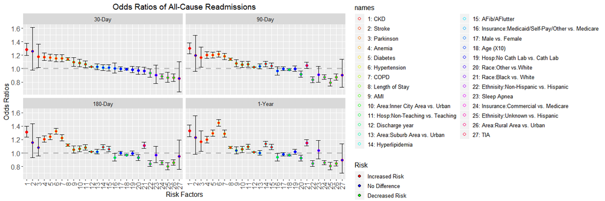

```r
# Plot OR----
p2a <- ggplot(t2a,
              aes(x = names,
                  y = coef)) +
  facet_wrap( ~ followup,
              ncol = 2) +
  geom_hline(yintercept = 1,
             colour = "grey",
             size = 1.1,
             linetype = 2) +
  geom_errorbar(aes(ymin = lb,
                    ymax = ub),
                size = 0.4,
                width = 0.8) +
  geom_point(aes(x = names,
                 y = coef,
                 colour = names,
                 fill = clr),
             size = 2,
             shape = 21) +
  scale_color_manual(labels = paste(1:nlevels(t2a$names),
                                    levels(t2a$names),
                                    sep = ": "),
                     values = rainbow(nlevels(t2a$names))) +
  scale_fill_manual("Risk",
                    labels = levels(t2a$clr),
                    values = c("red",
                               "blue",
                               "green")) +
  scale_x_discrete("Risk Factors",
                   labels = 1:nlevels(t2a$names)) +
  scale_y_continuous("Odds Ratios") +
  ggtitle("Odds Ratios of All-Cause Readmissions") +
  theme(axis.text.x = element_text(angle = 90,
                                   size = 12,
                                   hjust = 1,
                                   vjust = 0.5),
        axis.text.y = element_text(size = 12),
        text = element_text(size = 12),
        plot.title = element_text(hjust = 0.5))

# Save for publication
pp2a <- p2a +
  ggtitle("") +
  geom_point(aes(x = names,
                 y = coef,
                 fill = clr),
             size = 2,
             shape = 21,
             color = "black")+
  theme(legend.position = "none")

tiff(filename = "tmp/fig6.tiff",
     height = 5,
     width = 8,
     units = "in",
     res = 600,
     compression = "lzw+p")
print(pp2a)
graphics.off()

print(p2a)
```

## 15.3 HF Readmissions

```r
case$hf30 <- case$hf90 <- case$hf180 <- case$hf1y <- FALSE
case$hf30[case$days2post.hf.dx1 < 31] <- TRUE
case$hf90[case$days2post.hf.dx1 < 91] <- TRUE
case$hf180[case$days2post.hf.dx1 < 181] <- TRUE
case$hf1y[case$days2post.hf.dx1 < 366] <- TRUE

m2b.30 <- glm(hf30 ~ DSCYR +
                decade +
                SEX +
                RACE +
                HISPAN +
                PRIME +
                log2(los + 1) +
                haf +
                hami +
                hanemia  +
                hckd +
                hcopd +
                hdiab +
                hhyper +
                hlipid  +
                hosa +
                hpark +
                hstroke  +
                htia +
                CLAB +
                Area +
                Teach,
              family = binomial(logit),
              data = case)

m2b.90 <- glm(hf90 ~ DSCYR +
                decade +
                SEX +
                RACE +
                HISPAN +
                PRIME +
                log2(los + 1) +
                haf +
                hami +
                hanemia  +
                hckd +
                hcopd +
                hdiab +
                hhyper +
                hlipid  +
                hosa +
                hpark +
                hstroke  +
                htia +
                CLAB +
                Area +
                Teach,
              family = binomial(logit),
              data = case)

m2b.180 <- glm(hf180 ~ DSCYR +
                 decade +
                 SEX +
                 RACE +
                 HISPAN +
                 PRIME +
                 log2(los + 1) +
                 haf +
                 hami +
                 hanemia  +
                 hckd +
                 hcopd +
                 hdiab +
                 hhyper +
                 hlipid  +
                 hosa +
                 hpark +
                 hstroke  +
                 htia +
                 CLAB +
                 Area +
                 Teach,
               family = binomial(logit),
               data = case)

m2b.1y <- glm(hf1y ~ DSCYR +
                decade +
                SEX +
                RACE +
                HISPAN +
                PRIME +
                log2(los + 1) +
                haf +
                hami +
                hanemia  +
                hckd +
                hcopd +
                hdiab +
                hhyper +
                hlipid  +
                hosa +
                hpark +
                hstroke  +
                htia +
                CLAB +
                Area +
                Teach,
              family = binomial(logit),
              data = case)

# Combine
s2b <- list(summary(m2b.30),
            summary(m2b.90),
            summary(m2b.180),
            summary(m2b.1y))

t2b <- lapply(s2b, function(a) {
  out <- data.table(Level = rownames(a$coefficients)[-1],
                    names = t2.names,
                    coef = exp(a$coefficients[-1, 1]),
                    lb = exp(a$coefficients[-1, 1] - 1.96*a$coefficients[-1, 2]),
                    ub = exp(a$coefficients[-1, 1] + 1.96*a$coefficients[-1, 2]),
                    pval = ifelse(a$coefficients[-1, 4] >= 0.001,
                                  format(round(a$coefficients[-1, 4],
                                               3),
                                         digits = 3),
                                  "<0.001"),
                    sign = ifelse(a$coefficients[-1, 4] <= 0.05,
                                  ifelse(a$coefficients[-1, 4] <= 0.01,
                                         "**",
                                         "*"), ""))
  rownames(out) <- NULL
  return(out)
})

t2b <- do.call("rbind", t2b)

t2b <- data.table(followup = rep(c("30-Day",
                                   "90-Day",
                                   "180-Day",
                                   "1-Year"),
                                 each = length(t2.names)),
                  t2b)
t2b$names <- factor(t2b$names,
                    levels = unique(t2b$names))
t2b$followup <- factor(as.character(t2b$followup),
                       levels = c("30-Day",
                                  "90-Day",
                                  "180-Day",
                                  "1-Year"))

t2b$clr <- 2
t2b$clr[t2b$lb > 1] <- 1
t2b$clr[t2b$ub < 1] <- 3
t2b$clr <- factor(t2b$clr,
                  levels = 1:3,
                  labels = c("Increased Risk",
                             "No Difference",
                             "Decreased Risk"))

# Save Table 2b as CSV
t2b$est <- paste(round(t2b$coef, 3),
                 " (",
                 round(t2b$lb, 3),
                 ", ",
                 round(t2b$ub, 3),
                 ")\n",
                 t2b$pval,
                 sep = "")
table2b <- dcast.data.table(data = t2b,
                            Level + names ~ followup,
                            value.var = "est")
colnames(table2b)[2] <- "Risk Factor"

write.csv(table2b,
          file = "tmp/table2b.csv",
          row.names = FALSE)

tt1 <- apply(table2b[, -c(1:2)],
             MARGIN = 2,
             function(a) {
               substr(x = a,
                      start = nchar(a) - 4,
                      stop = nchar(a)) %>%
                 as.numeric()
             })
colnames(tt1) <- LETTERS[1:4]

tmp2b <- cbind(table2b,
               tt1)

# Relevels
tmp2b <- tmp2b[order(tmp2b$`30-Day`,
                     decreasing = TRUE), ]
lvls <- tmp2b$`Risk Factor`
tmp2b$`Risk Factor` <- factor(tmp2b$`Risk Factor`,
                              levels = lvls)
t2b$names <- factor(t2b$names,
                    levels = lvls)
write.csv(tmp2b,
          file = "tmp/table4.csv")

datatable(data = tmp2b,
          caption = "Table2B: HF Readmissions",
          class = "cell-border stripe",
          rownames = FALSE,
          options = list(searching = TRUE,
                         pageLength = nrow(table2b),
                         columnDefs = list(list(visible = FALSE,
                                                targets = 6:9)))) %>%
  formatStyle(columns = 3,
              valueColumns = 7,
              color = "black",
              backgroundColor = styleInterval(cuts = c(0.05),
                                              values = c("yellow",
                                                         "white"))) %>%
  formatStyle(columns = 4,
              valueColumns = 8,
              color = "black",
              backgroundColor = styleInterval(cuts = c(0.05),
                                              values = c("yellow",
                                                         "white"))) %>%
  formatStyle(columns = 5,
              valueColumns = 9,
              color = "black",
              backgroundColor = styleInterval(cuts = c(0.05),
                                              values = c("yellow",
                                                         "white"))) %>%
  formatStyle(columns = 6,
              valueColumns = 10,
              color = "black",
              backgroundColor = styleInterval(cuts = c(0.05),
                                              values = c("yellow",
                                                         "white")))
```

| Level | Risk Factor | 30-Day | 90-Day | 180-Day | 1-Year | A | B | C | D |
| --- | --- | --- | --- | --- | --- | --- | --- | --- | --- |
| hstrokeTRUE | Stroke | 1.834 (1.299, 2.589) &lt;0.001 | 1.362 (1.011, 1.835) 0.042 | 1.307 (1, 1.71) 0.050 | 1.432 (1.127, 1.818) 0.003 | 0.001 | 0.042 | 0.05 | 0.003 |
| CLABNo Cath Lab | Hosp:No Cath Lab vs. Cath Lab | 1.232 (1.145, 1.326) &lt;0.001 | 1.135 (1.072, 1.202) &lt;0.001 | 1.099 (1.045, 1.156) &lt;0.001 | 1.061 (1.014, 1.11) 0.010 | 0.001 | 0.001 | 0.001 | 0.01 |
| hamiTRUE | AMI | 1.185 (1.077, 1.305) &lt;0.001 | 1.176 (1.092, 1.266) &lt;0.001 | 1.134 (1.062, 1.211) &lt;0.001 | 1.128 (1.064, 1.197) &lt;0.001 | 0.001 | 0.001 | 0.001 | 0.001 |
| PRIMEmedicaid/self-pay/other | Insurance:Medicaid/Self-Pay/Other vs. Medicare | 1.165 (1.044, 1.3) 0.006 | 1.237 (1.135, 1.348) &lt;0.001 | 1.18 (1.093, 1.275) &lt;0.001 | 1.162 (1.084, 1.246) &lt;0.001 | 0.006 | 0.001 | 0.001 | 0.001 |
| SEXM | Male vs. Female | 1.118 (1.057, 1.183) &lt;0.001 | 1.088 (1.041, 1.136) &lt;0.001 | 1.081 (1.041, 1.124) &lt;0.001 | 1.082 (1.045, 1.12) &lt;0.001 | 0.001 | 0.001 | 0.001 | 0.001 |
| AreaSuburb | Area:Suburb Area vs. Urban | 1.117 (1.042, 1.199) 0.002 | 1.05 (0.994, 1.108) 0.080 | 1.06 (1.01, 1.112) 0.017 | 1.042 (0.998, 1.088) 0.060 | 0.002 | 0.08 | 0.017 | 0.06 |
| hdiabTRUE | Diabetes | 1.108 (1.032, 1.189) 0.005 | 1.144 (1.084, 1.207) &lt;0.001 | 1.167 (1.113, 1.224) &lt;0.001 | 1.214 (1.164, 1.267) &lt;0.001 | 0.005 | 0.001 | 0.001 | 0.001 |
| RACEBlack | Race:Black vs. White | 1.078 (0.994, 1.17) 0.071 | 1.177 (1.105, 1.253) &lt;0.001 | 1.257 (1.19, 1.328) &lt;0.001 | 1.315 (1.252, 1.382) &lt;0.001 | 0.071 | 0.001 | 0.001 | 0.001 |
| hckdTRUE | CKD | 1.074 (0.954, 1.21) 0.237 | 1.067 (0.974, 1.168) 0.166 | 1.049 (0.968, 1.137) 0.246 | 1.05 (0.976, 1.129) 0.192 | 0.237 | 0.166 | 0.246 | 0.192 |
| log2(los + 1) | Length of Stay | 1.063 (1.032, 1.094) &lt;0.001 | 1.064 (1.04, 1.088) &lt;0.001 | 1.071 (1.049, 1.092) &lt;0.001 | 1.055 (1.036, 1.074) &lt;0.001 | 0.001 | 0.001 | 0.001 | 0.001 |

[output cut: 17 more lines]

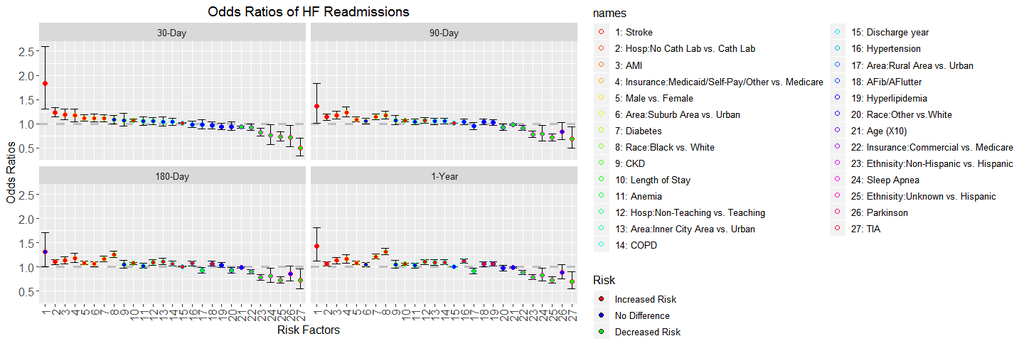

```r
# Plot OR----
p2b <- ggplot(t2b,
              aes(x = names,
                  y = coef)) +
  facet_wrap( ~ followup,
              ncol = 2) +
  geom_hline(yintercept = 1,
             colour = "grey",
             size = 1.1,
             linetype = 2) +
  geom_errorbar(aes(ymin = lb,
                    ymax = ub),
                size = 0.4,
                width = 0.8) +
  geom_point(aes(x = names,
                 y = coef,
                 colour = names,
                 fill = clr),
             size = 2,
             shape = 21) +
  scale_color_manual(labels = paste(1:nlevels(t2b$names),
                                    levels(t2b$names),
                                    sep = ": "),
                     values = rainbow(nlevels(t2b$names))) +
  scale_fill_manual("Risk",
                    labels = levels(t2b$clr),
                    values = c("red",
                               "blue",
                               "green")) +
  scale_x_discrete("Risk Factors",
                   labels = 1:nlevels(t2b$names)) +
  scale_y_continuous("Odds Ratios") +
  ggtitle("Odds Ratios of HF Readmissions") +
  theme(axis.text.x = element_text(angle = 90,
                                   size = 12,
                                   hjust = 1,
                                   vjust = 0.5),
        axis.text.y = element_text(size = 12),
        text = element_text(size = 12),
        plot.title = element_text(hjust = 0.5))

# Save for publication
pp2b <- p2b +
  ggtitle("") +
  geom_point(aes(x = names,
                 y = coef,
                 fill = clr),
             size = 2,
             shape = 21,
             color = "black")+
  theme(legend.position = "none")
tiff(filename = "tmp/fig7.tiff",
     height = 5,
     width = 8,
     units = "in",
     res = 600,
     compression = "lzw+p")
print(pp2b)
graphics.off()

print(p2b)
```

## 15.4 All-Cause Death

```r
case$dead30 <- case$dead90 <- case$dead180 <- case$dead1y <- FALSE
case$dead30[case$days2death < 31] <- TRUE
case$dead90[case$days2death < 91] <- TRUE
case$dead180[case$days2death < 181] <- TRUE
case$dead1y[case$days2death < 366] <- TRUE

m2c.30 <- glm(dead30 ~ DSCYR +
                decade +
                SEX +
                RACE +
                HISPAN +
                PRIME +
                log2(los + 1) +
                haf +
                hami +
                hanemia  +
                hckd +
                hcopd +
                hdiab +
                hhyper +
                hlipid  +
                hosa +
                hpark +
                hstroke  +
                htia +
                CLAB +
                Area +
                Teach,
              family = binomial(logit),
              data = case)

m2c.90 <- glm(dead90 ~ DSCYR +
                decade +
                SEX +
                RACE +
                HISPAN +
                PRIME +
                log2(los + 1) +
                haf +
                hami +
                hanemia  +
                hckd +
                hcopd +
                hdiab +
                hhyper +
                hlipid  +
                hosa +
                hpark +
                hstroke  +
                htia +
                CLAB +
                Area +
                Teach,
              family = binomial(logit),
              data = case)

m2c.180 <- glm(dead180 ~ DSCYR +
                 decade +
                 SEX +
                 RACE +
                 HISPAN +
                 PRIME +
                 log2(los + 1) +
                 haf +
                 hami +
                 hanemia  +
                 hckd +
                 hcopd +
                 hdiab +
                 hhyper +
                 hlipid  +
                 hosa +
                 hpark +
                 hstroke  +
                 htia +
                 CLAB +
                 Area +
                 Teach,
               family = binomial(logit),
               data = case)

m2c.1y <- glm(dead1y ~ DSCYR +
                decade +
                SEX +
                RACE +
                HISPAN +
                PRIME +
                log2(los + 1) +
                haf +
                hami +
                hanemia  +
                hckd +
                hcopd +
                hdiab +
                hhyper +
                hlipid  +
                hosa +
                hpark +
                hstroke  +
                htia +
                CLAB +
                Area +
                Teach,
              family = binomial(logit),
              data = case)

# Combine
s2c <- list(summary(m2c.30),
            summary(m2c.90),
            summary(m2c.180),
            summary(m2c.1y))

t2c <- lapply(s2c, function(a) {
  out <- data.table(Level = rownames(a$coefficients)[-1],
                    names = t2.names,
                    coef = exp(a$coefficients[-1, 1]),
                    lb = exp(a$coefficients[-1, 1] - 1.96*a$coefficients[-1, 2]),
                    ub = exp(a$coefficients[-1, 1] + 1.96*a$coefficients[-1, 2]),
                    pval = ifelse(a$coefficients[-1, 4] >= 0.001,
                                  format(round(a$coefficients[-1, 4],
                                               3),
                                         digits = 3),
                                  "<0.001"),
                    sign = ifelse(a$coefficients[-1, 4] <= 0.05,
                                  ifelse(a$coefficients[-1, 4] <= 0.01,
                                         "**",
                                         "*"), ""))
  rownames(out) <- NULL
  return(out)
})

t2c <- do.call("rbind", t2c)

t2c <- data.table(followup = rep(c("30-Day",
                                   "90-Day",
                                   "180-Day",
                                   "1-Year"),
                                 each = length(t2.names)),
                  t2c)
t2c$names <- factor(t2c$names,
                    levels = unique(t2c$names))
t2c$followup <- factor(as.character(t2c$followup),
                       levels = c("30-Day",
                                  "90-Day",
                                  "180-Day",
                                  "1-Year"))

t2c$clr <- 2
t2c$clr[t2c$lb > 1] <- 1
t2c$clr[t2c$ub < 1] <- 3
t2c$clr <- factor(t2c$clr,
                  levels = 1:3,
                  labels = c("Increased Risk",
                             "No Difference",
                             "Decreased Risk"))

# Save Table 2c as CSV
t2c$est <- paste(round(t2c$coef, 3),
                 " (",
                 round(t2c$lb, 3),
                 ", ",
                 round(t2c$ub, 3),
                 ")\n",
                 t2c$pval,
                 sep = "")
table2c <- dcast.data.table(data = t2c,
                            Level + names ~ followup,
                            value.var = "est")
colnames(table2c)[2] <- "Risk Factor"

write.csv(table2c,
          file = "tmp/table2c.csv",
          row.names = FALSE)

tt1 <- apply(table2c[, -c(1:2)],
             MARGIN = 2,
             function(a) {
               substr(x = a,
                      start = nchar(a) - 4,
                      stop = nchar(a)) %>%
                 as.numeric()
             })
colnames(tt1) <- LETTERS[1:4]

tmp2c <- cbind(table2c,
               tt1)

# Relevels
tmp2c <- tmp2c[order(tmp2c$`30-Day`,
                     decreasing = TRUE), ]
lvls <- tmp2c$`Risk Factor`
tmp2c$`Risk Factor` <- factor(tmp2c$`Risk Factor`,
                              levels = lvls)
t2c$names <- factor(t2c$names,
                    levels = lvls)
write.csv(tmp2c,
          file = "tmp/table5.csv")

datatable(data = tmp2c,
          caption = "Table2C: All-Cause Death",
          class = "cell-border stripe",
          rownames = FALSE,
          options = list(searching = TRUE,
                         pageLength = nrow(table2c),
                         columnDefs = list(list(visible = FALSE,
                                                targets = 6:9)))) %>%
  formatStyle(columns = 3,
              valueColumns = 7,
              color = "black",
              backgroundColor = styleInterval(cuts = c(0.05),
                                              values = c("yellow",
                                                         "white"))) %>%
  formatStyle(columns = 4,
              valueColumns = 8,
              color = "black",
              backgroundColor = styleInterval(cuts = c(0.05),
                                              values = c("yellow",
                                                         "white"))) %>%
  formatStyle(columns = 5,
              valueColumns = 9,
              color = "black",
              backgroundColor = styleInterval(cuts = c(0.05),
                                              values = c("yellow",
                                                         "white"))) %>%
  formatStyle(columns = 6,
              valueColumns = 10,
              color = "black",
              backgroundColor = styleInterval(cuts = c(0.05),
                                              values = c("yellow",
                                                         "white")))
```

| Level | Risk Factor | 30-Day | 90-Day | 180-Day | 1-Year | A | B | C | D |
| --- | --- | --- | --- | --- | --- | --- | --- | --- | --- |
| log2(los + 1) | Length of Stay | 1.725 (1.661, 1.792) &lt;0.001 | 1.664 (1.619, 1.71) &lt;0.001 | 1.582 (1.546, 1.62) &lt;0.001 | 1.485 (1.455, 1.515) &lt;0.001 | 0.001 | 0.001 | 0.001 | 0.001 |
| decade | Age (X10) | 1.65 (1.593, 1.71) &lt;0.001 | 1.617 (1.578, 1.658) &lt;0.001 | 1.601 (1.568, 1.634) &lt;0.001 | 1.587 (1.559, 1.615) &lt;0.001 | 0.001 | 0.001 | 0.001 | 0.001 |
| HISPANNon-Hispanic | Ethnisity:Non-Hispanic vs. Hispanic | 1.378 (1.165, 1.63) &lt;0.001 | 1.349 (1.203, 1.512) &lt;0.001 | 1.401 (1.273, 1.542) &lt;0.001 | 1.436 (1.325, 1.557) &lt;0.001 | 0.001 | 0.001 | 0.001 | 0.001 |
| HISPANUnknown | Ethnisity:Unknown vs. Hispanic | 1.357 (1.113, 1.655) 0.003 | 1.35 (1.178, 1.548) &lt;0.001 | 1.372 (1.223, 1.539) &lt;0.001 | 1.381 (1.253, 1.522) &lt;0.001 | 0.003 | 0.001 | 0.001 | 0.001 |
| hparkTRUE | Parkinson | 1.296 (1.02, 1.647) 0.034 | 1.468 (1.239, 1.74) &lt;0.001 | 1.36 (1.168, 1.583) &lt;0.001 | 1.353 (1.18, 1.551) &lt;0.001 | 0.034 | 0.001 | 0.001 | 0.001 |
| hckdTRUE | CKD | 1.282 (1.118, 1.47) &lt;0.001 | 1.335 (1.209, 1.473) &lt;0.001 | 1.338 (1.229, 1.456) &lt;0.001 | 1.384 (1.285, 1.491) &lt;0.001 | 0.001 | 0.001 | 0.001 | 0.001 |
| hstrokeTRUE | Stroke | 1.228 (0.774, 1.949) 0.383 | 1.541 (1.131, 2.099) 0.006 | 1.634 (1.254, 2.129) &lt;0.001 | 1.512 (1.188, 1.925) &lt;0.001 | 0.383 | 0.006 | 0.001 | 0.001 |
| hamiTRUE | AMI | 1.202 (1.068, 1.353) 0.002 | 1.243 (1.142, 1.352) &lt;0.001 | 1.219 (1.135, 1.31) &lt;0.001 | 1.235 (1.16, 1.314) &lt;0.001 | 0.002 | 0.001 | 0.001 | 0.001 |
| hanemiaTRUE | Anemia | 1.181 (1.078, 1.293) &lt;0.001 | 1.168 (1.094, 1.247) &lt;0.001 | 1.284 (1.215, 1.357) &lt;0.001 | 1.317 (1.255, 1.382) &lt;0.001 | 0.001 | 0.001 | 0.001 | 0.001 |
| SEXM | Male vs. Female | 1.177 (1.097, 1.263) &lt;0.001 | 1.166 (1.109, 1.226) &lt;0.001 | 1.177 (1.128, 1.228) &lt;0.001 | 1.176 (1.133, 1.22) &lt;0.001 | 0.001 | 0.001 | 0.001 | 0.001 |

[output cut: 17 more lines]

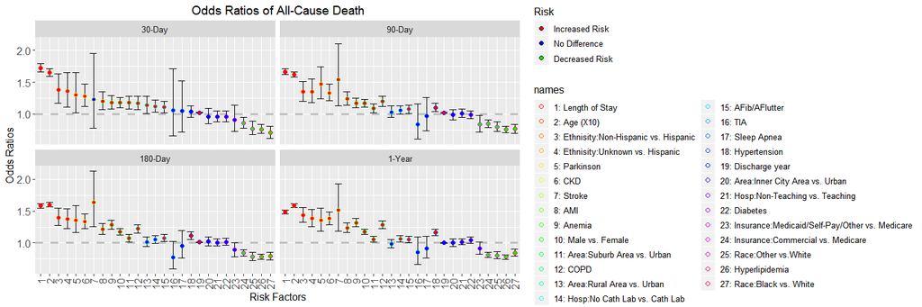

```r
# Plot OR----
p2c <- ggplot(t2c,
              aes(x = names,
                  y = coef)) +
  facet_wrap( ~ followup,
              ncol = 2) +
  geom_hline(yintercept = 1,
             colour = "grey",
             size = 1.1,
             linetype = 2) +
  geom_errorbar(aes(ymin = lb,
                    ymax = ub),
                size = 0.4,
                width = 0.8) +
  geom_point(aes(x = names,
                 y = coef,
                 colour = names,
                 fill = clr),
             size = 2,
             shape = 21) +
  scale_color_manual(labels = paste(1:nlevels(t2c$names),
                                    levels(t2c$names),
                                    sep = ": "),
                     values = rainbow(nlevels(t2c$names))) +
  scale_fill_manual("Risk",
                    labels = levels(t2c$clr),
                    values = c("red",
                               "blue",
                               "green")) +
  scale_x_discrete("Risk Factors",
                   labels = 1:nlevels(t2c$names)) +
  scale_y_continuous("Odds Ratios") +
  ggtitle("Odds Ratios of All-Cause Death") +
  theme(axis.text.x = element_text(angle = 90,
                                   size = 12,
                                   hjust = 1,
                                   vjust = 0.5),
        axis.text.y = element_text(size = 12),
        text = element_text(size = 12),
        plot.title = element_text(hjust = 0.5))

# Save for publication
pp2c <- p2c +
  ggtitle("") +
  geom_point(aes(x = names,
                 y = coef,
                 fill = clr),
             size = 2,
             shape = 21,
             color = "black")+
  theme(legend.position = "none")
tiff(filename = "tmp/fig8.tiff",
     height = 5,
     width = 8,
     units = "in",
     res = 600,
     compression = "lzw+p")
print(pp2c)
graphics.off()

print(p2c)
```

## 15.5 CV Death

```r
case$cvdeath30 <- case$cvdeath90 <- case$cvdeath180 <- case$cvdeath1y <- FALSE
case$cvdeath30[case$days2cvdeath < 31] <- TRUE
case$cvdeath90[case$days2cvdeath < 91] <- TRUE
case$cvdeath180[case$days2cvdeath < 181] <- TRUE
case$cvdeath1y[case$days2cvdeath < 366] <- TRUE

m2d.30 <- glm(cvdeath30 ~ DSCYR +
                decade +
                SEX +
                RACE +
                HISPAN +
                PRIME +
                log2(los + 1) +
                haf +
                hami +
                hanemia  +
                hckd +
                hcopd +
                hdiab +
                hhyper +
                hlipid  +
                hosa +
                hpark +
                hstroke  +
                htia +
                CLAB +
                Area +
                Teach,
              family = binomial(logit),
              data = case)

m2d.90 <- glm(cvdeath90 ~ DSCYR +
                decade +
                SEX +
                RACE +
                HISPAN +
                PRIME +
                log2(los + 1) +
                haf +
                hami +
                hanemia  +
                hckd +
                hcopd +
                hdiab +
                hhyper +
                hlipid  +
                hosa +
                hpark +
                hstroke  +
                htia +
                CLAB +
                Area +
                Teach,
              family = binomial(logit),
              data = case)

m2d.180 <- glm(cvdeath180 ~ DSCYR +
                 decade +
                 SEX +
                 RACE +
                 HISPAN +
                 PRIME +
                 log2(los + 1) +
                 haf +
                 hami +
                 hanemia  +
                 hckd +
                 hcopd +
                 hdiab +
                 hhyper +
                 hlipid  +
                 hosa +
                 hpark +
                 hstroke  +
                 htia +
                 CLAB +
                 Area +
                 Teach,
               family = binomial(logit),
               data = case)

m2d.1y <- glm(cvdeath1y ~ DSCYR +
                decade +
                SEX +
                RACE +
                HISPAN +
                PRIME +
                log2(los + 1) +
                haf +
                hami +
                hanemia  +
                hckd +
                hcopd +
                hdiab +
                hhyper +
                hlipid  +
                hosa +
                hpark +
                hstroke  +
                htia +
                CLAB +
                Area +
                Teach,
              family = binomial(logit),
              data = case)

# Combine
s2d <- list(summary(m2d.30),
            summary(m2d.90),
            summary(m2d.180),
            summary(m2d.1y))

t2d <- lapply(s2d, function(a) {
  out <- data.table(Level = rownames(a$coefficients)[-1],
                    names = t2.names,
                    coef = exp(a$coefficients[-1, 1]),
                    lb = exp(a$coefficients[-1, 1] - 1.96*a$coefficients[-1, 2]),
                    ub = exp(a$coefficients[-1, 1] + 1.96*a$coefficients[-1, 2]),
                    pval = ifelse(a$coefficients[-1, 4] >= 0.001,
                                  format(round(a$coefficients[-1, 4],
                                               3),
                                         digits = 3),
                                  "<0.001"),
                    sign = ifelse(a$coefficients[-1, 4] <= 0.05,
                                  ifelse(a$coefficients[-1, 4] <= 0.01,
                                         "**",
                                         "*"), ""))
  rownames(out) <- NULL
  return(out)
})

t2d <- do.call("rbind", t2d)

t2d <- data.table(followup = rep(c("30-Day",
                                   "90-Day",
                                   "180-Day",
                                   "1-Year"),
                                 each = length(t2.names)),
                  t2d)
t2d$names <- factor(t2d$names,
                    levels = unique(t2d$names))
t2d$followup <- factor(as.character(t2d$followup),
                       levels = c("30-Day",
                                  "90-Day",
                                  "180-Day",
                                  "1-Year"))

t2d$clr <- 2
t2d$clr[t2d$lb > 1] <- 1
t2d$clr[t2d$ub < 1] <- 3
t2d$clr <- factor(t2d$clr,
                  levels = 1:3,
                  labels = c("Increased Risk",
                             "No Difference",
                             "Decreased Risk"))

# Save Table 2d as CSV
t2d$est <- paste(round(t2d$coef, 3),
                 " (",
                 round(t2d$lb, 3),
                 ", ",
                 round(t2d$ub, 3),
                 ")\n",
                 t2d$pval,
                 sep = "")
table2d <- dcast.data.table(data = t2d,
                            Level + names ~ followup,
                            value.var = "est")
colnames(table2d)[2] <- "Risk Factor"

write.csv(table2d,
          file = "tmp/table2d.csv",
          row.names = FALSE)

tt1 <- apply(table2d[, -c(1:2)],
             MARGIN = 2,
             function(a) {
               substr(x = a,
                      start = nchar(a) - 4,
                      stop = nchar(a)) %>%
                 as.numeric()
             })
colnames(tt1) <- LETTERS[1:4]

tmp2d <- cbind(table2d,
               tt1)

# Relevels
tmp2d <- tmp2d[order(tmp2d$`30-Day`,
                     decreasing = TRUE), ]
lvls <- tmp2d$`Risk Factor`
tmp2d$`Risk Factor` <- factor(tmp2d$`Risk Factor`,
                              levels = lvls)
t2d$names <- factor(t2d$names,
                    levels = lvls)

datatable(data = tmp2d,
          caption = "Table2D: CV Death",
          class = "cell-border stripe",
          rownames = FALSE,
          options = list(searching = TRUE,
                         pageLength = nrow(table2d),
                         columnDefs = list(list(visible = FALSE,
                                                targets = 6:9)))) %>%
  formatStyle(columns = 3,
              valueColumns = 7,
              color = "black",
              backgroundColor = styleInterval(cuts = c(0.05),
                                              values = c("yellow",
                                                         "white"))) %>%
  formatStyle(columns = 4,
              valueColumns = 8,
              color = "black",
              backgroundColor = styleInterval(cuts = c(0.05),
                                              values = c("yellow",
                                                         "white"))) %>%
  formatStyle(columns = 5,
              valueColumns = 9,
              color = "black",
              backgroundColor = styleInterval(cuts = c(0.05),
                                              values = c("yellow",
                                                         "white"))) %>%
  formatStyle(columns = 6,
              valueColumns = 10,
              color = "black",
              backgroundColor = styleInterval(cuts = c(0.05),
                                              values = c("yellow",
                                                         "white")))
```

| Level | Risk Factor | 30-Day | 90-Day | 180-Day | 1-Year | A | B | C | D |
| --- | --- | --- | --- | --- | --- | --- | --- | --- | --- |
| hstrokeTRUE | Stroke | 2.047 (1.081, 3.877) 0.028 | 1.894 (1.24, 2.893) 0.003 | 1.892 (1.344, 2.662) &lt;0.001 | 1.734 (1.292, 2.328) &lt;0.001 | 0.028 | 0.003 | 0.001 | 0.001 |
| HISPANUnknown | Ethnisity:Unknown vs. Hispanic | 1.645 (1.15, 2.352) 0.006 | 1.544 (1.241, 1.92) &lt;0.001 | 1.499 (1.261, 1.782) &lt;0.001 | 1.397 (1.217, 1.603) &lt;0.001 | 0.006 | 0.001 | 0.001 | 0.001 |
| log2(los + 1) | Length of Stay | 1.605 (1.503, 1.713) &lt;0.001 | 1.536 (1.473, 1.601) &lt;0.001 | 1.418 (1.372, 1.466) &lt;0.001 | 1.335 (1.299, 1.372) &lt;0.001 | 0.001 | 0.001 | 0.001 | 0.001 |
| HISPANNon-Hispanic | Ethnisity:Non-Hispanic vs. Hispanic | 1.587 (1.164, 2.164) 0.003 | 1.48 (1.227, 1.785) &lt;0.001 | 1.517 (1.309, 1.757) &lt;0.001 | 1.452 (1.293, 1.63) &lt;0.001 | 0.003 | 0.001 | 0.001 | 0.001 |
| decade | Age (X10) | 1.391 (1.31, 1.477) &lt;0.001 | 1.495 (1.439, 1.553) &lt;0.001 | 1.52 (1.475, 1.566) &lt;0.001 | 1.513 (1.477, 1.551) &lt;0.001 | 0.001 | 0.001 | 0.001 | 0.001 |
| hamiTRUE | AMI | 1.306 (1.067, 1.598) 0.010 | 1.377 (1.215, 1.56) &lt;0.001 | 1.326 (1.2, 1.464) &lt;0.001 | 1.337 (1.232, 1.45) &lt;0.001 | 0.01 | 0.001 | 0.001 | 0.001 |
| SEXM | Male vs. Female | 1.215 (1.074, 1.375) 0.002 | 1.143 (1.057, 1.236) &lt;0.001 | 1.167 (1.097, 1.242) &lt;0.001 | 1.18 (1.122, 1.241) &lt;0.001 | 0.002 | 0.001 | 0.001 | 0.001 |
| TeachNon-Teaching | Hosp:Non-Teaching vs. Teaching | 1.165 (1, 1.359) 0.051 | 1.151 (1.044, 1.268) 0.005 | 1.104 (1.022, 1.193) 0.012 | 1.113 (1.045, 1.186) &lt;0.001 | 0.051 | 0.005 | 0.012 | 0.001 |
| hanemiaTRUE | Anemia | 1.14 (0.968, 1.342) 0.117 | 1.04 (0.938, 1.153) 0.457 | 1.144 (1.056, 1.24) &lt;0.001 | 1.155 (1.082, 1.234) &lt;0.001 | 0.117 | 0.457 | 0.001 | 0.001 |
| hhyperTRUE | Hypertension | 1.065 (0.914, 1.239) 0.420 | 1.097 (0.997, 1.207) 0.058 | 1.166 (1.08, 1.258) &lt;0.001 | 1.172 (1.101, 1.247) &lt;0.001 | 0.42 | 0.058 | 0.001 | 0.001 |

[output cut: 17 more lines]

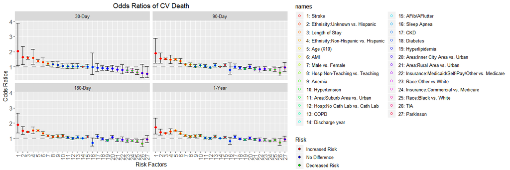

```r
# Plot OR----
p2d <- ggplot(t2d,
              aes(x = names,
                  y = coef)) +
  facet_wrap( ~ followup,
              ncol = 2) +
  geom_hline(yintercept = 1,
             colour = "grey",
             size = 1.1,
             linetype = 2) +
  geom_errorbar(aes(ymin = lb,
                    ymax = ub),
                size = 0.4,
                width = 0.8) +
  geom_point(aes(x = names,
                 y = coef,
                 colour = names,
                 fill = clr),
             size = 2,
             shape = 21) +
  scale_color_manual(labels = paste(1:nlevels(t2d$names),
                                    levels(t2d$names),
                                    sep = ": "),
                     values = rainbow(nlevels(t2d$names))) +
  scale_fill_manual("Risk",
                    labels = levels(t2d$clr),
                    values = c("red",
                               "blue",
                               "green")) +
  scale_x_discrete("Risk Factors",
                   labels = 1:nlevels(t2d$names)) +
  scale_y_continuous("Odds Ratios") +
  ggtitle("Odds Ratios of CV Death") +
  theme(axis.text.x = element_text(angle = 90,
                                   size = 12,
                                   hjust = 1,
                                   vjust = 0.5),
        axis.text.y = element_text(size = 12),
        text = element_text(size = 12),
        plot.title = element_text(hjust = 0.5))

# Save for publication
pp2d <- p2d +
  ggtitle("") +
  geom_point(aes(x = names,
                 y = coef,
                 fill = clr),
             size = 2,
             shape = 21,
             color = "black")+
  theme(legend.position = "none")
tiff(filename = "tmp/fig9.tiff",
     height = 5,
     width = 8,
     units = "in",
     res = 600,
     compression = "lzw+p")
print(pp2d)
graphics.off()

print(p2d)
```

# 16 Association of 1-Year Readmission with 3-Year All-Cause Mortality

## 16.1 3-year all-cause mortality vs. 1-year readmission, unadjusted logistic model

```r
# Keep only the patients discharged before 2013
# => everyone has at least 3-year follow-up
case2 <- case2[DSCYR < 2013, ]
print(paste("Number of patients discharged between 2000 and 2012 =",
            nrow(case2)))
```

```
[1] "Number of patients discharged between 2000 and 2012 = 82145"
```

```r
case2$dead3y <- FALSE
case2$dead3y[case2$days2death < 3*365.25] <- TRUE

#

mm1.3y <- glm(dead3y ~ readm1y,
              family = binomial(logit),
              data = case2)
ss1 <-summary(mm1.3y)

out1 <- data.table(names = "Readmitted within 1 year",
                   coef = exp(ss1$coefficients[-1, 1]),
                   lb = exp(ss1$coefficients[-1, 1] - 1.96*ss1$coefficients[-1, 2]),
                   ub = exp(ss1$coefficients[-1, 1] + 1.96*ss1$coefficients[-1, 2]),
                   pval = ifelse(ss1$coefficients[-1, 4] >= 0.001,
                                 round(ss1$coefficients[-1, 4], 3),
                                 "<0.001"),
                   sign = ifelse(ss1$coefficients[-1, 4] <= 0.05,
                                 ifelse(ss1$coefficients[-1, 4] <= 0.01,
                                        "**",
                                        "*"), ""))
datatable(data = out1,
          caption = "Logistic regression models of 1-year all-cause readmission vs. 3-year all-cause death",
          class = "cell-border stripe",
          rownames = FALSE,
          options = list(searching = FALSE,
                         pageLength = nrow(t1))) %>%
  formatRound(columns = 2:4,
              digits = 3)
```

| names | coef | lb | ub | pval | sign |
| --- | --- | --- | --- | --- | --- |
| Readmitted within 1 year | 1.66333161337467 | 1.6151641209113 | 1.71293555882766 | &lt;0.001 | ** |

Risk of death within 3 years from initial HF discharge was significantly higher in patients who were readmitted for any cause within 1 year from the said discharge (OR = 1.66, 95% C.I. = 1.62 to 1.71, p-value < 0.001).

## 16.2 3-year all-cause death vs. 1-year readmission, adjusted for all covariates

```r
# Remove patients from hosps with no info
tmp <- droplevels(case2[Area != "Unknown", ])
# 3,353 patients with no info about the admission hospital were removed; 89,893 remained

mm2.3y <- glm(dead3y ~ readm1y +
                DSCYR +
                decade +
                SEX +
                RACE +
                HISPAN +
                PRIME +
                log2(los + 1) +
                haf +
                hami +
                hanemia  +
                hckd +
                hcopd +
                hdiab +
                hhyper +
                hlipid  +
                hosa +
                hpark +
                hstroke  +
                htia +
                CLAB +
                Area +
                Teach,
              family = binomial(logit),
              data = tmp)
ss1 <-summary(mm2.3y)

out2 <- data.table(Level = rownames(ss1$coefficients)[-1],
                   names = c("1-Year All-Cause Readmission",
                             t2.names),
                   coef = exp(ss1$coefficients[-1, 1]),
                   lb = exp(ss1$coefficients[-1, 1] - 1.96*ss1$coefficients[-1, 2]),
                   ub = exp(ss1$coefficients[-1, 1] + 1.96*ss1$coefficients[-1, 2]),
                   pval = ifelse(ss1$coefficients[-1, 4] >= 0.001,
                                 format(round(ss1$coefficients[-1, 4],
                                              3),
                                        digits = 3),
                                 "<0.001"),
                   sign = ifelse(ss1$coefficients[-1, 4] <= 0.05,
                                 ifelse(ss1$coefficients[-1, 4] <= 0.01,
                                        "**",
                                        "*"), ""))

# Relevels
out2 <- out2[order(out2$coef,
                   decreasing = TRUE), ]
out2$names <- factor(out2$names,
                     levels = out2$names)

out2$clr <- 2
out2$clr[out2$lb > 1] <- 1
out2$clr[out2$ub < 1] <- 3
out2$clr <- factor(out2$clr,
                   levels = 1:3,
                   labels = c("Increased Risk",
                              "No Difference",
                              "Decreased Risk"))

datatable(data = out2[, -ncol(out2), with = FALSE],
          caption = "Table: 3-year cause of death vs. 1-year readmission, adjusted",
          class = "cell-border stripe",
          rownames = FALSE,
          options = list(searching = FALSE,
                         pageLength = nrow(out2))) %>%
  formatRound(columns = 3:5,
              digits = 3)
```

| Level | names | coef | lb | ub | pval | sign |
| --- | --- | --- | --- | --- | --- | --- |
| readm1yTRUE | 1-Year All-Cause Readmission | 1.61633424120662 | 1.56406258102499 | 1.67035284328897 | &lt;0.001 | ** |
| hparkTRUE | Parkinson | 1.61232261529458 | 1.40154878717402 | 1.85479395336067 | &lt;0.001 | ** |
| decade | Age (X10) | 1.58857755375711 | 1.5642192290108 | 1.61331519105337 | &lt;0.001 | ** |
| hckdTRUE | CKD | 1.57976295581949 | 1.46203406441641 | 1.70697185333756 | &lt;0.001 | ** |
| hstrokeTRUE | Stroke | 1.53764999774503 | 1.20659452129931 | 1.95953775177037 | &lt;0.001 | ** |
| HISPANNon-Hispanic | Ethnisity:Non-Hispanic vs. Hispanic | 1.50026369741667 | 1.40190711352356 | 1.6055208936983 | &lt;0.001 | ** |
| HISPANUnknown | Ethnisity:Unknown vs. Hispanic | 1.47479142308969 | 1.35668856758027 | 1.60317540340018 | &lt;0.001 | ** |
| hanemiaTRUE | Anemia | 1.40098630770525 | 1.33772723195511 | 1.46723680844036 | &lt;0.001 | ** |
| log2(los + 1) | Length of Stay | 1.37971736585267 | 1.35484859236053 | 1.40504261536619 | &lt;0.001 | ** |
| hcopdTRUE | COPD | 1.32702322039645 | 1.26874451620381 | 1.38797890747965 | &lt;0.001 | ** |

[output cut: 18 more lines]

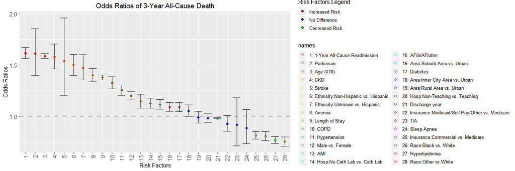

```r
write.csv(out2,
          file = "tmp/legend_for_fig5.csv")

# Plot OR----
p1 <- ggplot(out2,
             aes(x = names,
                 y = coef)) +
  geom_hline(yintercept = 1,
             colour = "grey",
             size = 1.1,
             linetype = 2) +
  geom_errorbar(aes(ymin = lb,
                    ymax = ub),
                size = 0.4,
                width = 0.8) +
  geom_point(aes(x = names,
                 y = coef,
                 colour = names,
                 fill = clr),
             size = 2,
             shape = 21) +
  scale_color_manual(labels = paste(1:nlevels(out2$names),
                                    levels(out2$names),
                                    sep = ": "),
                     values = rainbow(nlevels(out2$names))) +
  scale_fill_manual("Risk",
                    labels = levels(out2$clr),
                    values = c("red",
                               "blue",
                               "green")) +
  scale_x_discrete("Risk Factors",
                   labels = 1:nlevels(out2$names)) +
  scale_y_continuous("Odds Ratios") +
  ggtitle("Odds Ratios of 3-Year All-Cause Death") +
  theme(axis.text.x = element_text(angle = 90,
                                   size = 12,
                                   hjust = 1,
                                   vjust = 0.5),
        axis.text.y = element_text(size = 12),
        text = element_text(size = 12),
        plot.title = element_text(hjust = 0.5)) +
  guides(fill = guide_legend("Risk Factors Legend"))

# Save for publication
pp1 <- p1 +
  ggtitle("") +
  geom_point(aes(x = names,
                 y = coef,
                 fill = clr),
             size = 2,
             shape = 21,
             color = "black")+
  theme(legend.position = "none")
tiff(filename = "tmp/fig5.tiff",
     height = 5,
     width = 8,
     units = "in",
     res = 600,
     compression = "lzw+p")
print(pp1)
graphics.off()

print(p1)
```

## 16.3 3-year mortality

```r
t7 <- addmargins(table(case2$group,
                       case2$dead3y))

tab7 <- data.table(Reason = rownames(t7),
                   Alive = format(t7[, 1],
                                  big.mark = ","),
                   Alive_Pct = round(100*t7[, 1]/t7[, 3], 1),
                   Dead = format(t7[, 2],
                                 big.mark = ","),
                   Dead_Pct = round(100*t7[, 2]/t7[, 3], 1),
                   Total = format(t7[, 3],
                                  big.mark = ","))

tab7$Reason <- factor(tab7$Reason,
                      levels = rev(c("Sum",
                                     "Not Readmitted",
                                     "Other Reason",
                                     "Cerebrovascular",
                                     "Procedures",
                                     "AMI",
                                     "Hypertension",
                                     "Diabetes mellitus",
                                     "General symptoms",
                                     "Infections",
                                     "Kidney Disease",
                                     "Arrhythmia",
                                     "Heart Disease",
                                     "Respiratory",
                                     "Heart failure")))
setkey(tab7,
       Reason)

datatable(tab7,
          caption = "Table: number and percent dead in 3 years",
          class = "cell-border stripe",
          rownames = FALSE,
          options = list(searching = TRUE,
                         pageLength = nrow(tab7)))
```

| Reason | Alive | Alive_Pct | Dead | Dead_Pct | Total |
| --- | --- | --- | --- | --- | --- |
| Heart failure | 5,779 | 56.2 | 4,509 | 43.8 | 10,288 |
| Respiratory | 2,365 | 59.7 | 1,597 | 40.3 | 3,962 |
| Heart Disease | 2,363 | 78.7 | 640 | 21.3 | 3,003 |
| Arrhythmia | 1,554 | 70.5 | 650 | 29.5 | 2,204 |
| Kidney Disease | 1,345 | 51.6 | 1,261 | 48.4 | 2,606 |
| Infections | 596 | 49.3 | 613 | 50.7 | 1,209 |
| General symptoms | 621 | 63.5 | 357 | 36.5 | 978 |
| Diabetes mellitus | 644 | 62 | 394 | 38 | 1,038 |
| Hypertension | 566 | 61.7 | 352 | 38.3 | 918 |
| AMI | 587 | 47.5 | 650 | 52.5 | 1,237 |

[output cut: 5 more lines]

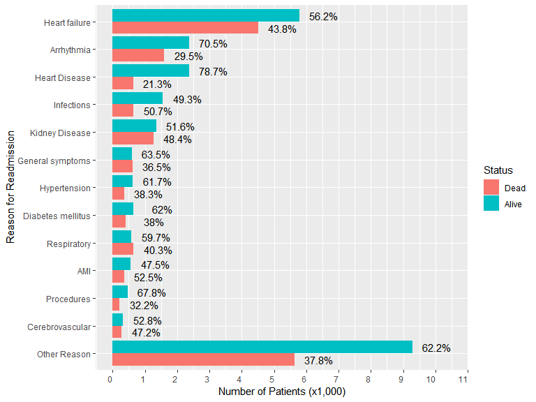

```r
tab7$Alive <- t7[, 1]
tab7$Dead <- t7[, 2]

stts <- melt.data.table(data = tab7,
                        id.vars = 1,
                        measure.vars = c(2, 4),
                        variable.name = "3-Year Status",
                        value.name = "N")
tmp <- melt.data.table(data = tab7,
                       id.vars = 1,
                       measure.vars = c(3, 5),
                       variable.name = "3-Year Status",
                       value.name = "Percent")
tmp$`3-Year Status` <- gsub(pattern = "_Pct",
                            replacement = "",
                            x = tmp$`3-Year Status`)
stts <- merge(stts,
              tmp,
              by = c("Reason",
                     "3-Year Status"))
stts$`3-Year Status` <- factor(stts$`3-Year Status`,
                               levels = c("Dead",
                                          "Alive"))
stts <- droplevels(stts[!(Reason %in% c("Not Readmitted",
                                        "Sum"))])
stts$Reason <- factor(stts$Reason,
                      levels = c("Other Reason",
                                 "Cerebrovascular",
                                 "Procedures",
                                 "AMI",
                                 "Respiratory",
                                 "Diabetes mellitus",
                                 "Hypertension",
                                 "General symptoms",
                                 "Kidney Disease",
                                 "Infections",
                                 "Heart Disease",
                                 "Arrhythmia",
                                 "Heart failure"))

p1 <- ggplot(stts,
             aes(x = Reason,
                 y = N,
                 group = `3-Year Status`,
                 fill = `3-Year Status`)) +
  coord_flip() +
  geom_bar(stat = "identity",
           position = position_dodge(0.9)) +
  scale_x_discrete("Reason for Readmission") +
  scale_y_continuous("Number of Patients (x1,000)",
                     breaks = seq(0,
                                  11000,
                                  by = 1000),
                     labels = seq(0,
                                  11,
                                  by = 1)) +
  scale_fill_discrete("Status") +
  geom_text(aes(x = Reason,
                y = N + 1200,
                angle = 0,
                label = paste(Percent,
                              "%",
                              sep = "")),
            hjust = 1,
            size = 4,
            position = position_dodge(0.9)) +
  theme(axis.text.x = element_text(angle = 0,
                                   hjust = 1))

tiff(filename = "tmp/fig10.tiff",
     height = 6,
     width = 8,
     units = "in",
     res = 600,
     compression = "lzw+p")
print(p1)
graphics.off()

print(p1)
```

## 16.4 Odds ratios of 3-year all-cause death by reason for readmission, vs. HF readmission

```r
lvls <- c("Heart failure",
          "AMI",
          "Infections",
          "Kidney Disease",
          "Cerebrovascular",
          "Respiratory",
          "Hypertension",
          "Diabetes mellitus",
          "Other Reason",
          "General symptoms",
          "Procedures",
          "Arrhythmia",
          "Heart Disease",
          "Not Readmitted")

case2$group <- factor(case2$group,
                      levels = lvls)

mm3.3y <- glm(dead3y ~ group,
              family = binomial(logit),
              data = case2)

# Combine
ss1 <- (summary(mm3.3y))

out3 <- data.table(names = factor(levels(case2$group)[-1],
                                  levels = levels(case2$group)[-1]),
                   coef = round(exp(ss1$coefficients[-1, 1]), 3),
                   lb = round(exp(ss1$coefficients[-1, 1] - 1.96*ss1$coefficients[-1, 2]), 3),
                   ub = round(exp(ss1$coefficients[-1, 1] + 1.96*ss1$coefficients[-1, 2]), 3),
                   pval = ifelse(ss1$coefficients[-1, 4] >= 0.001,
                                 round(ss1$coefficients[-1, 4], 3),
                                 "<0.001"),
                   sign = ifelse(ss1$coefficients[-1, 4] <= 0.05,
                                 ifelse(ss1$coefficients[-1, 4] <= 0.01,
                                        "**",
                                        "*"), ""))

datatable(out3,
          caption = "Table: 3-year mortality vs. reason for readmission",
          class = "cell-border stripe",
          rownames = FALSE,
          options = list(searching = TRUE,
                         pageLength = nrow(out3)))
```

| names | coef | lb | ub | pval | sign |
| --- | --- | --- | --- | --- | --- |
| AMI | 1.419 | 1.261 | 1.597 | &lt;0.001 | ** |
| Infections | 1.318 | 1.17 | 1.485 | &lt;0.001 | ** |
| Kidney Disease | 1.202 | 1.102 | 1.31 | &lt;0.001 | ** |
| Cerebrovascular | 1.145 | 0.971 | 1.35 | 0.108 |  |
| Respiratory | 0.865 | 0.803 | 0.932 | &lt;0.001 | ** |
| Hypertension | 0.797 | 0.694 | 0.916 | 0.001 | ** |
| Diabetes mellitus | 0.784 | 0.688 | 0.894 | &lt;0.001 | ** |
| Other Reason | 0.777 | 0.739 | 0.818 | &lt;0.001 | ** |
| General symptoms | 0.737 | 0.643 | 0.844 | &lt;0.001 | ** |
| Procedures | 0.609 | 0.516 | 0.718 | &lt;0.001 | ** |

[output cut: 3 more lines]

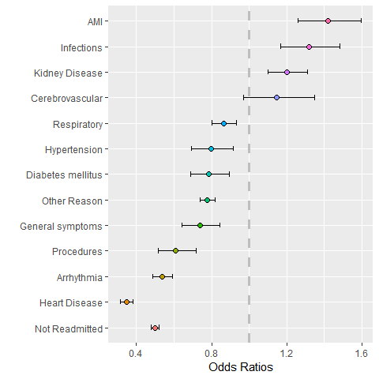

```r
out3$names <- factor(out3$names,
                     levels = rev(levels(out3$names)))
p4 <- ggplot(out3,
             aes(x = names,
                 y = coef)) +
  coord_flip() +
  geom_hline(yintercept = 1,
             colour = "grey",
             size = 1.1,
             linetype = 2) +
  geom_errorbar(aes(ymin = lb,
                    ymax = ub),
                size = 0.4,
                width = 0.2) +
  geom_point(aes(x = names,
                 y = coef,
                 fill = names),
             size = 2,
             shape = 21) +
  scale_x_discrete("") +
  scale_y_continuous("Odds Ratios") +
  theme(legend.position = "none")

# Save for publication
tiff(filename = "tmp/fig4.tiff",
     height = 5,
     width = 5,
     units = "in",
     res = 600,
     compression = "lzw+p")
print(p4)
graphics.off()

p4
```

Compare to risk of 3-year (from the index HF discharge) all-cause mortality after the first HF readmission, not being readmitted or being readmitted for the first time for heart disease, respiratory problems, arrhythmia, diabetes, general symptoms, hypertension, procedures or other reasons decreased the risk. On the other hand, readmission for kidney disease or infections increased the risk.

## 16.5 Odds ratios of 3-year all-cause death by reason for readmission, vs. no readmission

```r
lvls <- c("Not Readmitted",
          "AMI",
          "Infections",
          "Kidney Disease",
          "Cerebrovascular",
          "Heart failure",
          "Respiratory",
          "Hypertension",
          "Diabetes mellitus",
          "Other Reason",
          "General symptoms",
          "Procedures",
          "Arrhythmia",
          "Heart Disease")

case2$group <- factor(case2$group,
                      levels = lvls)

mm3.3y <- glm(dead3y ~ group,
              family = binomial(logit),
              data = case2)

# Combine
ss1 <- (summary(mm3.3y))

out3 <- data.table(names = factor(levels(case2$group)[-1],
                                  levels = levels(case2$group)[-1]),
                   coef = round(exp(ss1$coefficients[-1, 1]), 3),
                   lb = round(exp(ss1$coefficients[-1, 1] - 1.96*ss1$coefficients[-1, 2]), 3),
                   ub = round(exp(ss1$coefficients[-1, 1] + 1.96*ss1$coefficients[-1, 2]), 3),
                   pval = ifelse(ss1$coefficients[-1, 4] >= 0.001,
                                 round(ss1$coefficients[-1, 4], 3),
                                 "<0.001"),
                   sign = ifelse(ss1$coefficients[-1, 4] <= 0.05,
                                 ifelse(ss1$coefficients[-1, 4] <= 0.01,
                                        "**",
                                        "*"), ""))

datatable(out3,
          caption = "Table: 3-year mortality vs. reason for readmission",
          class = "cell-border stripe",
          rownames = FALSE,
          options = list(searching = TRUE,
                         pageLength = nrow(out3)))
```

| names | coef | lb | ub | pval | sign |
| --- | --- | --- | --- | --- | --- |
| AMI | 2.843 | 2.537 | 3.186 | &lt;0.001 | ** |
| Infections | 2.641 | 2.354 | 2.962 | &lt;0.001 | ** |
| Kidney Disease | 2.407 | 2.222 | 2.608 | &lt;0.001 | ** |
| Cerebrovascular | 2.293 | 1.951 | 2.695 | &lt;0.001 | ** |
| Heart failure | 2.003 | 1.915 | 2.095 | &lt;0.001 | ** |
| Respiratory | 1.734 | 1.621 | 1.854 | &lt;0.001 | ** |
| Hypertension | 1.597 | 1.395 | 1.827 | &lt;0.001 | ** |
| Diabetes mellitus | 1.571 | 1.383 | 1.784 | &lt;0.001 | ** |
| Other Reason | 1.557 | 1.496 | 1.621 | &lt;0.001 | ** |
| General symptoms | 1.476 | 1.293 | 1.684 | &lt;0.001 | ** |

[output cut: 3 more lines]

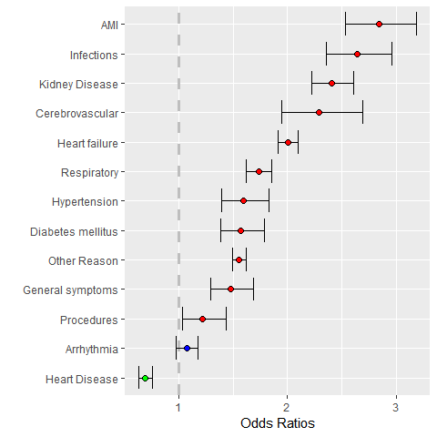

```r
out3$names <- factor(out3$names,
                     levels = rev(levels(out3$names)))

out3$clr <- 2
out3$clr[out3$lb > 1] <- 1
out3$clr[out3$ub < 1] <- 3
out3$clr <- factor(out3$clr,
                   levels = 1:3,
                   labels = c("Increased Risk",
                              "No Difference",
                              "Decreased Risk"))
p4 <- ggplot(out3,
             aes(x = names,
                 y = coef)) +
  coord_flip() +
  geom_hline(yintercept = 1,
             colour = "grey",
             size = 1.1,
             linetype = 2) +
  geom_errorbar(aes(ymin = lb,
                    ymax = ub),
                size = 0.4,
                width = 0.8) +
  geom_point(aes(x = names,
                 y = coef,
                 fill = clr),
             size = 2,
             shape = 21) +
  scale_x_discrete("") +
  scale_y_continuous("Odds Ratios") +
  scale_fill_manual("Risk",
                    labels = levels(out3$clr),
                    values = c("red",
                               "blue",
                               "green")) +
  theme(legend.position = "none")

p4
```

```r
case2$days2death3y <- case2$days2death
case2$days2death3y[case2$days2death3y > 3*365.25 |
                     is.na(case2$days2death3y)] <- ceiling(3*365.25)
sf1 <- survfit(Surv(days2death3y,
                    dead3y) ~ readm1y,
               data = case2)
sf1
```

```
Call: survfit(formula = Surv(days2death3y, dead3y) ~ readm1y, data = case2)

                  n events median 0.95LCL 0.95UCL
readm1y=FALSE 38500  10792     NA      NA      NA
readm1y=TRUE  43645  17159     NA      NA      NA
```

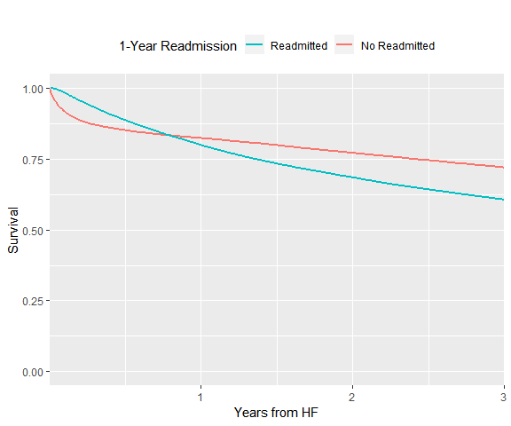

```r
# Extract data from the fit
dt.surv <- data.table(Time = sf1$time,
                      HR = sf1$surv,
                      Group = rep(names(sf1$strata),
                                  sf1$strata))

# Plot
p1 <- ggplot(dt.surv,
             aes(x = Time,
                 y = HR,
                 colour = Group,
                 group = Group)) +
  geom_step(size = 1) +
  scale_x_continuous("Years from HF",
                     breaks = seq(0, 3*365.25, by = 365.25),
                     labels = seq(0, 3, by = 1),
                     expand = c(0, 0)) +
  scale_y_continuous("Survival",
                     limits = c(0, 1)) +
  scale_color_discrete("1-Year Readmission",
                       breaks = c("readm1y=TRUE",
                                  "readm1y=FALSE"),
                       labels = c("Readmitted",
                                  "No Readmitted")) +
  ggtitle("") +
  theme(legend.position = "top")

# Save for publication
tiff(filename = "tmp/fig11.tiff",
     height = 5,
     width = 6,
     units = "in",
     res = 600,
     compression = "lzw+p")
print(p1)
graphics.off()

p1
```

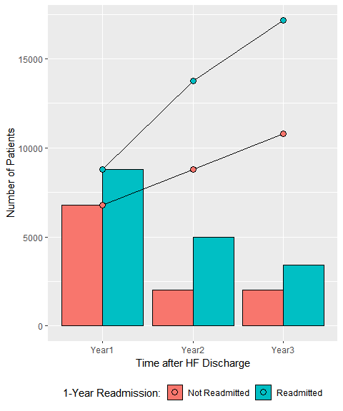

```r
case2$dead2y <- FALSE
case2$dead2y[case2$days2death < 2*365.25] <- TRUE

dtt <- rbindlist(list(data.table(year = "Year1",
                          table(readm1y = case2$readm1y,
                                dead = case2$dead1y)),
               data.table(year = "Year2",
                          table(readm1y = case2$readm1y,
                                dead = case2$dead2y &
                                  !case2$dead1y)),
               data.table(year = "Year3",
                          table(readm1y = case2$readm1y,
                                dead = case2$dead3y &
                                  !(case2$dead2y | case2$dead1y)))))
dtt$xx <- paste(dtt$year,
                dtt$readm1y,
                sep = "_")
dtt <- dtt[dead == "TRUE", ]
dtt[, ycum := cumsum(N),
    by = readm1y]
dtt$xcum <- seq(from = 0.5,
                by = 1,
                length.out = 6)



p1 <- ggplot(data = dtt,
       aes(x = year,
           y = N,
           fill = readm1y,
           group = readm1y)) +
  geom_bar(stat = "identity",
           color = "black",
           position = position_dodge(0.9)) +
  geom_line(aes(y = ycum,
                group = readm1y)) +
  geom_point(aes(y = ycum,
                 group = readm1y,
                 fill = readm1y),
             shape = 21,
             size = 3) +
  scale_x_discrete("Time after HF Discharge") +
  scale_y_continuous("Number of Patients") +
  scale_fill_discrete("1-Year Readmission:",
                      breaks = c("FALSE",
                                 "TRUE"),
                      labels = c("Not Readmitted",
                                 "Readmitted")) +
  theme(legend.position = "bottom")

# Save for publication
tiff(filename = "tmp/fig12.tiff",
     height = 6,
     width = 5,
     units = "in",
     res = 600,
     compression = "lzw+p")
print(p1)
graphics.off()

p1
```

```r
dtt$N_total <- rep(table(case2$readm1y), 3)
dtt$pct <- dtt$N/dtt$N_total
datatable(dtt,
          rownames = FALSE,
          class = "cell-border stripe",
          options = list(searching = FALSE,
                         pageLength = nrow(dtt))) %>%
  formatCurrency(columns = c(4, 6, 8),
                 currency = "",
                 digits = 0,
                 mark = ",") %>%
  formatPercentage(columns = 9,
                   digits = 2)
```

| year | readm1y | dead | N | xx | ycum | xcum | N_total | pct |
| --- | --- | --- | --- | --- | --- | --- | --- | --- |
| Year1 | FALSE | TRUE | 6779 | Year1_FALSE | 6779 | 0.5 | 38500 | 0.176077922077922 |
| Year1 | TRUE | TRUE | 8779 | Year1_TRUE | 8779 | 1.5 | 43645 | 0.201145606598694 |
| Year2 | FALSE | TRUE | 2003 | Year2_FALSE | 8782 | 2.5 | 38500 | 0.052025974025974 |
| Year2 | TRUE | TRUE | 4979 | Year2_TRUE | 13758 | 3.5 | 43645 | 0.114079505097949 |
| Year3 | FALSE | TRUE | 2010 | Year3_FALSE | 10792 | 4.5 | 38500 | 0.0522077922077922 |
| Year3 | TRUE | TRUE | 3401 | Year3_TRUE | 17159 | 5.5 | 43645 | 0.0779241608431665 |

```r
t1 <- addmargins(table(readm1y = case2$readm1y,
                       dead3y = case2$dead3y))

t2 <- as.matrix(table(readm1y = case2$readm1y,
            dead3y = case2$dead3y))
chisq.test(t2)
```

```
    Pearson's Chi-squared test with Yates' continuity correction

data:  t2
X-squared = 1159.7, df = 1, p-value < 2.2e-16
```

To remove the survival curve crossing, we sampled (with replacement) the number of days to readmission from the readmitted subpopulation and assign a number of days to pseudo-readmission in non-readmitted subpopulation. We then removed all non-readmitted patients for whom this pseudo-readmission date was assigned after the date of death.

First, we looked at the distribution of number of days to death in each subpopulations:

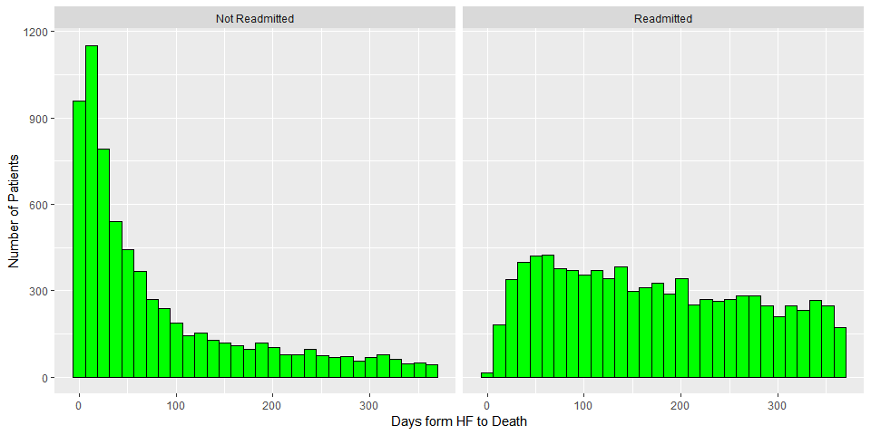

```r
p1 <- ggplot(data = case2[days2death < 366, ] ,
             aes(x = days2death)) +
  facet_wrap(~ readm1y,
             labeller = as_labeller(c("FALSE" = "Not Readmitted",
                                      "TRUE" = "Readmitted"))) +
  geom_histogram(fill = "green",
                 color = "black") +
  scale_x_continuous("Days form HF to Death") +
  scale_y_continuous("Number of Patients")
print(p1)
```

Next, we assigned pseudo-readmission dates to non-readmitted patients as above:

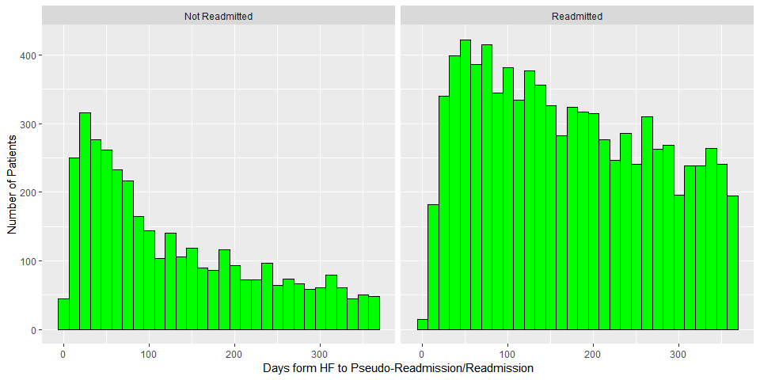

```r
ndays2readm <- case2$days2readm[case2$days2death < 366]
ndays2readm <- ndays2readm[!is.na(ndays2readm)]

# Randomly assign pseudo-readmission days to non-readmitted patients
# Use data from the admitted patients
tmp <- case2[case2$readm1y == FALSE &
               !is.na(case2$days2death), ]
tmp$pseudodays <- sample(x = ndays2readm,
                         size = nrow(tmp),
                         replace = TRUE)

id.rm <- tmp$Patient_ID[tmp$days2death <= tmp$pseudodays]

case3 <- case2[!Patient_ID %in% id.rm, ]
p2 <-  ggplot(data = case3[days2death < 366, ] ,
              aes(x = days2death)) +
  facet_wrap(~ readm1y,
             labeller = as_labeller(c("FALSE" = "Not Readmitted",
                                      "TRUE" = "Readmitted"))) +
  geom_histogram(fill = "green",
                 color = "black") +
  scale_x_continuous("Days form HF to Pseudo-Readmission/Readmission") +
  scale_y_continuous("Number of Patients")
print(p2)
```

Lastly, we redrew survival curves:

```r
sf1 <- survfit(Surv(days2death3y,
                    dead3y) ~ readm1y,
               data = case3)
sf1
```

```
Call: survfit(formula = Surv(days2death3y, dead3y) ~ readm1y, data = case3)

                  n events median 0.95LCL 0.95UCL
readm1y=FALSE 35326   7618     NA      NA      NA
readm1y=TRUE  43645  17159     NA      NA      NA
```

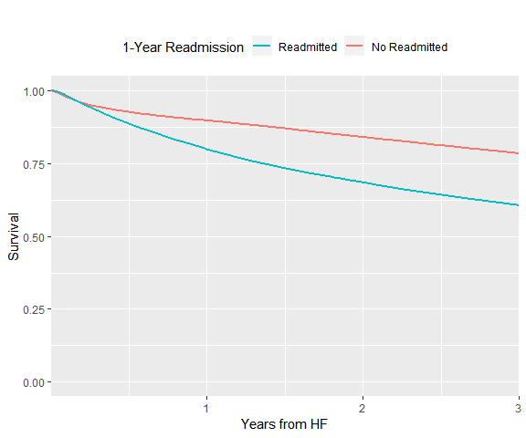

```r
# Extract data from the fit
dt.surv <- data.table(Time = sf1$time,
                      HR = sf1$surv,
                      Group = rep(names(sf1$strata),
                                  sf1$strata))

# Plot
p3 <- ggplot(dt.surv,
             aes(x = Time,
                 y = HR,
                 colour = Group,
                 group = Group)) +
  geom_step(size = 1) +
  scale_x_continuous("Years from HF",
                     breaks = seq(0, 3*365.25, by = 365.25),
                     labels = seq(0, 3, by = 1),
                     expand = c(0, 0)) +
  scale_y_continuous("Survival",
                     limits = c(0, 1)) +
  scale_color_discrete("1-Year Readmission",
                       breaks = c("readm1y=TRUE",
                                  "readm1y=FALSE"),
                       labels = c("Readmitted",
                                  "No Readmitted")) +
  ggtitle("") +
  theme(legend.position = "top")

# Save for publication
tiff(filename = "tmp/fig13.tiff",
     height = 5,
     width = 6,
     units = "in",
     res = 600,
     compression = "lzw+p")
print(p3)
graphics.off()

p3
```

The curves still cross but much less and much earlier than in the original graph.

# 17 Appendix

## 17.1 Data Preprocessing

**SOURCE**: *source/midas15_hf_data_v1.R*  
* MIDAS-2015 contains 18,057,028 records of 4,446,438 patients.  
* Removed ER records. 17,271,297 records of 4,310,486 patients left.  
* Records from 115 NJ hospitals.  
* Admitted from 01/01/1995 to 31/12/2015.  
* Excluded cancer and HIV patients (946,835 and 23,718 patients respectively, possible overlap).  
* Records aggregated to 1 record per patient.

## 17.2 Statistics

### 17.2.1 Phi Correlation coefficient

The correlation between the binary variables was assessed using Phi statistic (Pearson correlation coefficient for binary variables) as follows:  
$\phi^2 = \frac{n_{11}*n_{00}-n_{10}*n_{01}}{\sqrt{n_{1\bullet}*n_{0\bullet}*n_{\bullet0}*n_{\bullet1}}}$ where the *n*-s are from the following 2X2 table:

```r
dtt <- data.table(`y = 1` = c("n11", "n01", "n.1"),
                  `y = 0` = c("n10", "n00", "n.0"),
                  `total` = c("n1.", "n0.", "n"))
rownames(dtt) <- c("x = 1", "x = 0", "total")
datatable(dtt)
```

|  | y = 1 | y = 0 | total |
| --- | --- | --- | --- |
| x = 1 | n11 | n10 | n1. |
| x = 0 | n01 | n00 | n0. |
| total | n.1 | n.0 | n |

## 17.3 ICD Codes

### 17.3.1 Diagnoses (ICD-9)

**NOTE**: cancer and HIV were the exclusion criteria.

| Comorbidity | Variable | ICD9 |
| --- | --- | --- |
| AFib/AFlutter | af | 427.31; 427.32 |
| AMI | ami | 410.00; 410.01; 410.02; 410.10; 410.11; 410.12; 410.20; 410.21; 410.22; 410.30; 410.31; 410.32; 410.40; 410.41; 410.42; 410.50; 410.51; 410.52; 410.60; 410.61; 410.62; 410.70; 410.71; 410.72; 410.80; … |
| Anemia | anemia | 280.0; 280.1; 280.8; 280.9; 281.0; 281.1; 281.2; 281.3; 281.4; 281.8; 281.9; 285.21; 285.29; 285.8; 285.9 |
| CKD | ckd | 585.1; 585.2; 585.3; 585.4; 585.5; 585.6; 585.9 |
| COPD | copd | 490; 491.0; 491.1; 491.20; 491.21; 491.22; 491.8; 491.9; 492.0; 492.8; 493.00; 493.01; 493.02; 493.10; 493.11; 493.12; 493.20; 493.21; 493.22; 493.81; 493.82; 493.90; 493.91; 493.92; 494.0; 494.1; 495… |
| Cancer | cancer | 140.3; 140.4; 140.0; 140.1; 140.9; 140.8; 140.5; 140.6; 141.9; 141.3; 141.0; 141.2; 141.8; 141.4; 141.5; 141.6; 141.1; 142.1; 142.2; 142.8; 142.9; 142.0; 143.0; 143.9; 143.8; 143.1; 144.9; 144.0; 144.… |
| Diabetes | diab | 250.00; 250.01; 250.02; 250.03; 250.10; 250.11; 250.12; 250.13; 250.20; 250.21; 250.22; 250.23; 250.30; 250.31; 250.32; 250.33; 250.40; 250.41; 250.42; 250.43; 250.50; 250.51; 250.52; 250.53; 250.60; … |
| HF | hf | 428.0; 428.1; 428.20; 428.21; 428.22; 428.23; 428.30; 428.31; 428.32; 428.33; 428.40; 428.41; 428.42; 428.43; 428.9 |
| HIV | hiv | 042 |
| Hyperlipidemia | lipid | 272.0; 272.1; 272.2; 272.3; 272.4; 272.5; 272.6; 272.7; 272.8; 272.9 |

[output cut: 5 more lines]

### 17.3.2 Cause of CV death (ICD-10)

```r
table2app <- data.table(Diagnosis = c("Major cardiovascular diseases",
                                      "Diseases of heart",
                                      "Hypertensive heart disease with or without renal disease",
                                      "Ischemic heart diseases",
                                      "Other diseases of heart",
                                      "Essential (primary) hypertension and hypertensive renal disease",
                                      "Cerebrovascular diseases",
                                      "Atherosclerosis",
                                      "Other diseases of circulatory system"),
                        `ICD-10` = c("I00-I78",
                                     "I00-I09, I11, I13, I20-I51",
                                     "I11,I13",
                                     "I20-I25",
                                     "I00-I09,I26-I51",
                                     "I10,I12",
                                     "I60-I69",
                                     "I70",
                                     "I71-I78"))
datatable(table2app,
          caption = "Appendix Table 2: CID-10 codes for cause of death",
          rownames = FALSE,
          class = "cell-border stripe",
          options = list(searching = TRUE,
                         pageLength = nrow(table2app)))
```

| Diagnosis | ICD-10 |
| --- | --- |
| Major cardiovascular diseases | I00-I78 |
| Diseases of heart | I00-I09, I11, I13, I20-I51 |
| Hypertensive heart disease with or without renal disease | I11,I13 |
| Ischemic heart diseases | I20-I25 |
| Other diseases of heart | I00-I09,I26-I51 |
| Essential (primary) hypertension and hypertensive renal disease | I10,I12 |
| Cerebrovascular diseases | I60-I69 |
| Atherosclerosis | I70 |
| Other diseases of circulatory system | I71-I78 |

## 17.4 Abbreviations

```r
# abbv <- data.table(Abbreviation = c("AMI",
#                                     "HF"),
#                    Description = c("Acute myocardial infarction",
#                                    "Heart failure"))
# setkey(abbv,
#        Abbreviation)
# DT::datatable(abbv,
#               caption = "Appendix Table 3: abbreviations",
#               class = "cell-border stripe",
#               options = list(searching = TRUE,
#                              pageLength = nrow(t1)))
```

## 17.5 Sources

## 17.6 References